# Actuarial Data Science Immersion - Ausarbeitung Teil 1

Dietmar Hareter

2025-05-10

# 1 R0: Bibliotheken, Reproduzierbarkeit und zentrale Hilfsfunktionen

Zunächst werden alle benötigten Pakete geladen, wichtige Punkte für die Reproduzierbarkeit aufgelistet, sowie die beiden Hilfsfunktionen aus SWoF definiert.

## 1.1 Laden der verwendete Pakete

Wie in der Aufgabenstellung gefordert, werden nur die benötigten Pakete geladen

```r
suppressPackageStartupMessages({
  # Visualisierung
  library(ggcorrplot)
  library(ggplot2)
  library(grid)

  # Datenmanipulation
  library(data.table)
  library(dplyr)
  library(purrr)
  library(rlang)
  library(splitstackshape)
  library(stringr)
  library(tibble)
  library(tidyr)

  # Modellierung
  library(caret)
  library(EIX)
  library(glmnet)
  library(hstats)
  library(mgcv)
  library(MLmetrics)
  library(nnet)
  library(xgboost)
})
```

## 1.2 Reproduzierbarkeit

Für die Reproduzierbarkeit werden folgende Punkte beachtet:

- Laden aller verwendeten Pakete - siehe voriger Abschnitt.
- Zufallszahlen werden mit *set.seed(…)* gesetzt.
- Verwendung der Funktion *sessionInfo()* am Ende des Notbooks, um alle technischen VOraussetzungen nachvollziehen zu können.
- Verwendung von relativen Pfaden bei der Einlese von Daten.
- Verwendung von *knitr::opts_chunk$set()*.
- Falls die Ausarbeitung in einem Projekt verwaltet werden würde (das ist hier nicht der Fall) könnten mit *renv* die verwendeten Pakete reproduzierbar gemacht werden.

## 1.3 Definition der verwendeten Hilfsfunktionen

Die beiden zentralen Hilfsfunktionen *multiplot* und *get_binCI* werden unverändert aus der Vorlage SWoF übernommen. In den folgenden Abschnitten werden weitere Hilfsfunktionen definiert. Diese sind aber nicht als “zentral” anzusehen und werden deshalb erst an den entsprechenden Anwendungsstellen definiert.

```r
# Definition einer Funktion für mehrere Plots
#
# ggplot-Objekte können entweder direkt über „...“ oder über „plotlist“ (als Liste von ggplot-Objekten) übergeben werden.
# - cols:   Anzahl der Spalten im Layout
# - layout: Eine Matrix, die das Layout angibt. Wenn vorhanden, wird 'cols' ignoriert.
#
# Wenn das Layout zum Beispiel so aussieht: matrix(c(1,2,3,3), nrow=2, byrow=TRUE),
# dann wird Plot 1 oben links, Plot 2 oben rechts und
# Plot 3 über die gesamte untere Reihe angezeigt.
#
multiplot <- function(..., plotlist=NULL, file, cols=1, layout=NULL) {

  # Erstelle eine Liste aus den ...-Argumenten und der plotlist.
  plots <- c(list(...), plotlist)

  numPlots = length(plots)

  # Wenn das Layout NULL ist, dann verwende 'cols' zur Bestimmung des Layouts
  if (is.null(layout)) {
    # Erstelle das Panel
    # ncol: Anzahl der Spalten der Plots
    # nrow: Benötigte Anzahl an Zeilen, berechnet anhand der Anzahl der Spalten
    layout <- matrix(seq(1, cols * ceiling(numPlots/cols)),
                    ncol = cols, nrow = ceiling(numPlots/cols))
  }

 if (numPlots==1) {
    print(plots[[1]])

  } else {
    # Seite einrichten
    grid.newpage()
    pushViewport(viewport(layout = grid.layout(nrow(layout), ncol(layout))))

    # Darstellung jedes Plota in der richtigen Position
    for (i in 1:numPlots) {
      # Ermittlung der i,j Matrix-Position der Felder, die den Subplot enthalten.
      matchidx <- as.data.frame(which(layout == i, arr.ind = TRUE))

      print(plots[[i]], vp = viewport(layout.pos.row = matchidx$row,
                                      layout.pos.col = matchidx$col))
    }
  }
}

# Funktion zur Ermittlung binomialer Konfidenzintervalle
get_binCI <- function(x,n) as.list(setNames(binom.test(x,n)$conf.int, c("lwr", "upr")))
```

# 2 R1: Datenaufbereitung

## 2.1 a) Daten einlesen

```r
diabetic_data_readin <- read.csv(file = "data/diabetic_data.csv", stringsAsFactors = TRUE)
```

Der Datensatz enthält 101.766 Zeilen und 50 Spalten.

Die ersten zehn Einträge sind:

```r
head(diabetic_data_readin, n = 10)
```

```
##    encounter_id patient_nbr            race gender      age weight
## 1       2278392     8222157       Caucasian Female   [0-10)      ?
## 2        149190    55629189       Caucasian Female  [10-20)      ?
## 3         64410    86047875 AfricanAmerican Female  [20-30)      ?
## 4        500364    82442376       Caucasian   Male  [30-40)      ?
## 5         16680    42519267       Caucasian   Male  [40-50)      ?
## 6         35754    82637451       Caucasian   Male  [50-60)      ?
## 7         55842    84259809       Caucasian   Male  [60-70)      ?
## 8         63768   114882984       Caucasian   Male  [70-80)      ?
## 9         12522    48330783       Caucasian Female  [80-90)      ?
## 10        15738    63555939       Caucasian Female [90-100)      ?
##    admission_type_id discharge_disposition_id admission_source_id
## 1                  6                       25                   1
## 2                  1                        1                   7
## 3                  1                        1                   7
```

[output cut: 95 more lines]

Für den Test, ob der Datensatz richtig eingelesen wurde, wird zunächst die Struktur der Daten geprüft. Insbesondere wird geprüft, ob alle Stings als Faktoren eingelesen wurden.

```r
str(diabetic_data_readin)
```

```
## 'data.frame':    101766 obs. of  50 variables:
##  $ encounter_id            : int  2278392 149190 64410 500364 16680 35754 55842 63768 12522 15738 ...
##  $ patient_nbr             : int  8222157 55629189 86047875 82442376 42519267 82637451 84259809 114882984 48330783 63555939 ...
##  $ race                    : Factor w/ 6 levels "?","AfricanAmerican",..: 4 4 2 4 4 4 4 4 4 4 ...
##  $ gender                  : Factor w/ 3 levels "Female","Male",..: 1 1 1 2 2 2 2 2 1 1 ...
##  $ age                     : Factor w/ 10 levels "[0-10)","[10-20)",..: 1 2 3 4 5 6 7 8 9 10 ...
##  $ weight                  : Factor w/ 10 levels "?","[0-25)","[100-125)",..: 1 1 1 1 1 1 1 1 1 1 ...
##  $ admission_type_id       : int  6 1 1 1 1 2 3 1 2 3 ...
##  $ discharge_disposition_id: int  25 1 1 1 1 1 1 1 1 3 ...
##  $ admission_source_id     : int  1 7 7 7 7 2 2 7 4 4 ...
##  $ time_in_hospital        : int  1 3 2 2 1 3 4 5 13 12 ...
##  $ payer_code              : Factor w/ 18 levels "?","BC","CH",..: 1 1 1 1 1 1 1 1 1 1 ...
##  $ medical_specialty       : Factor w/ 73 levels "?","AllergyandImmunology",..: 39 1 1 1 1 1 1 1 1 20 ...
##  $ num_lab_procedures      : int  41 59 11 44 51 31 70 73 68 33 ...
##  $ num_procedures          : int  0 0 5 1 0 6 1 0 2 3 ...
```

[output cut: 36 more lines]

Der Datensatz enthält kein Merkmal des Typs “character”, d.h. alle Strings wurden als Faktoren eingelesen.

Einen ersten Überblick über die einzelnen Merkmale gibt die Funktion *summary()*:

```r
summary(diabetic_data_readin)
```

```
##   encounter_id        patient_nbr                     race
##  Min.   :    12522   Min.   :      135   ?              : 2273
##  1st Qu.: 84961194   1st Qu.: 23413221   AfricanAmerican:19210
##  Median :152388987   Median : 45505143   Asian          :  641
##  Mean   :165201646   Mean   : 54330401   Caucasian      :76099
##  3rd Qu.:230270888   3rd Qu.: 87545950   Hispanic       : 2037
##  Max.   :443867222   Max.   :189502619   Other          : 1506
##
##              gender           age              weight      admission_type_id
##  Female         :54708   [70-80):26068   ?        :98569   Min.   :1.000
##  Male           :47055   [60-70):22483   [75-100) : 1336   1st Qu.:1.000
##  Unknown/Invalid:    3   [50-60):17256   [50-75)  :  897   Median :1.000
##                          [80-90):17197   [100-125):  625   Mean   :2.024
##                          [40-50): 9685   [125-150):  145   3rd Qu.:3.000
##                          [30-40): 3775   [25-50)  :   97   Max.   :8.000
##                          (Other): 5302   (Other)  :   97
##  discharge_disposition_id admission_source_id time_in_hospital   payer_code
##  Min.   : 1.000           Min.   : 1.000      Min.   : 1.000   ?      :40256
##  1st Qu.: 1.000           1st Qu.: 1.000      1st Qu.: 2.000   MC     :32439
##  Median : 1.000           Median : 7.000      Median : 4.000   HM     : 6274
##  Mean   : 3.716           Mean   : 5.754      Mean   : 4.396   SP     : 5007
##  3rd Qu.: 4.000           3rd Qu.: 7.000      3rd Qu.: 6.000   BC     : 4655
##  Max.   :28.000           Max.   :25.000      Max.   :14.000   MD     : 3532
##                                                                (Other): 9603
##               medical_specialty num_lab_procedures num_procedures
##  ?                     :49949   Min.   :  1.0      Min.   :0.00
##  InternalMedicine      :14635   1st Qu.: 31.0      1st Qu.:0.00
##  Emergency/Trauma      : 7565   Median : 44.0      Median :1.00
##  Family/GeneralPractice: 7440   Mean   : 43.1      Mean   :1.34
##  Cardiology            : 5352   3rd Qu.: 57.0      3rd Qu.:2.00
##  Surgery-General       : 3099   Max.   :132.0      Max.   :6.00
##  (Other)               :13726
##  num_medications number_outpatient number_emergency  number_inpatient
##  Min.   : 1.00   Min.   : 0.0000   Min.   : 0.0000   Min.   : 0.0000
##  1st Qu.:10.00   1st Qu.: 0.0000   1st Qu.: 0.0000   1st Qu.: 0.0000
##  Median :15.00   Median : 0.0000   Median : 0.0000   Median : 0.0000
##  Mean   :16.02   Mean   : 0.3694   Mean   : 0.1978   Mean   : 0.6356
##  3rd Qu.:20.00   3rd Qu.: 0.0000   3rd Qu.: 0.0000   3rd Qu.: 1.0000
##  Max.   :81.00   Max.   :42.0000   Max.   :76.0000   Max.   :21.0000
##
```

[output cut: 41 more lines]

```
##  No    :101753       No    :101765            No    :101764
##  Steady:    13       Steady:     1            Steady:     2
##
##
##
##
##
##  metformin.pioglitazone change     diabetesMed readmitted
##  No    :101765          Ch:47011   No :23403   <30:11357
##  Steady:     1          No:54755   Yes:78363   >30:35545
##                                                NO :54864
##
##
##
##
```

Die Anzahl der tatsächlich fehlenden Daten is 0, wie folgende Auswertung zeigt:

```r
sum(is.na(diabetic_data_readin))
```

```
## [1] 0
```

Ein Vorteil, wenn bei der Einlese der Daten keine *na.strings* verwendet werden (eine Vorgabe würde bedeuten, dass entsprechende Strings, wie beispielsweise ein Fragezeichen, bei der Einlese automatisch in einen *na*-Wert umgewandelt werden), ist, dass klar getrennt werden kann, ob Daten bereits im Datensatz selbst durch ein Fragezeichen als fehlend / na gekennzeichnet wurden, oder tatsächlich als Datenfeld fehlen (in diesem Fall wird der Wert bei der Einlese auf *na* gesetzt). Mit *sum(is.na())* kann die Anzahl der tatsächlich fehlenden Datensätze ermittelt werden.

Ein *na.string* könnte bei der Einlese folgendermaßen gesetzt werden:

read.csv(file = “data/diabetic_data.csv”, stringsAsFactors = TRUE, na.strings = “?”)

Der Nachteil bei fehlender Verwendung von *na.string* ist, dass die entsprechenden Datenfelder nicht automatisch als fehlende Wert behandelt / umgewandelt werden und somit zwei Arten von fehlenden Werten (direkt im Datansatz, beispielsweise mit einem Fragezeichen gekennzeichnet, bzw. tatsächlich fehlende) im Datensatz vorkommen. Das könnte zu einer fehlerhaften Analyse führen, wenn nicht beide Arten von fehlenden Werten entsprechend berücksichtig werden.

## 2.2 b) Daten filtern

Zunächst wird der Datensatz aufsteigend nach *patient_nbr* und dann nach *encounter_id* sortiert. Zur Überprüfung der korrekten Sortierung werden die ersten vier Spalten (damit die Anzeige in eine Zeile passt - die Darstellung aller Spalten ist für den Zweck nicht notwenig) der ersten 20 Beobachtungen ausgegeben und die entsprechenden *patient_nbr* gespeichert.

```r
diabetic_data_first <- diabetic_data_readin %>%
  dplyr::arrange(patient_nbr, encounter_id)
head(diabetic_data_first[,1:4], 20)
```

```
##    encounter_id patient_nbr            race gender
## 1      24437208         135       Caucasian Female
## 2      26264286         135       Caucasian Female
## 3      29758806         378       Caucasian Female
## 4     189899286         729       Caucasian Female
## 5      64331490         774       Caucasian Female
## 6      14824206         927 AfricanAmerican Female
## 7       8380170        1152 AfricanAmerican Female
## 8      30180318        1152 AfricanAmerican Female
## 9      55533660        1152 AfricanAmerican Female
## 10     80742510        1152 AfricanAmerican Female
## 11     83281464        1152 AfricanAmerican Female
## 12     66197028        1305       Caucasian Female
## 13     60254142        1314       Caucasian Female
## 14     70190028        1314       Caucasian Female
## 15     70601076        1314       Caucasian Female
## 16    171414378        1629       Caucasian   Male
## 17     14897280        2025       Caucasian Female
## 18     36469686        3069       Caucasian   Male
## 19     85907514        4302       Caucasian Female
## 20      7981038        5220       Caucasian   Male
```

```r
first_patient_nbr <- head(diabetic_data_first, 20) %>%
  dplyr::pull(patient_nbr)
```

Filtern nach dem ersten Datensatz je *patient_nbr* mit der Funktion *slice_head* aus dem Paket *dplyr*:

```r
diabetic_data_first <- diabetic_data_first %>%
  dplyr::group_by(patient_nbr) %>%
  dplyr::slice_head(n = 1) %>%
  dplyr::ungroup() %>%
  data.frame()

diabetic_data_first %>%
  dplyr::filter(patient_nbr %in% first_patient_nbr) %>%
  dplyr::select(dplyr::all_of(colnames(diabetic_data_readin)[1:4]))
```

```
##    encounter_id patient_nbr            race gender
## 1      24437208         135       Caucasian Female
## 2      29758806         378       Caucasian Female
## 3     189899286         729       Caucasian Female
## 4      64331490         774       Caucasian Female
## 5      14824206         927 AfricanAmerican Female
## 6       8380170        1152 AfricanAmerican Female
## 7      66197028        1305       Caucasian Female
## 8      60254142        1314       Caucasian Female
## 9     171414378        1629       Caucasian   Male
## 10     14897280        2025       Caucasian Female
## 11     36469686        3069       Caucasian   Male
## 12     85907514        4302       Caucasian Female
## 13      7981038        5220       Caucasian   Male
```

Die obige Auswertung zeigt, dass von den ersten 20 Beobachtungen des ursprünglichen Datensatzes nur mehr 13 Beobachtungen im gefilterten Datensatz vorhanden sind. Diese Beobachtungen entsprechen den ersten Einträgen pro *patient_nbr* in der oberen Auswertung.

Ein weiterer Test zur Überprüfung der Korrektheit der vorangegangenen Filterung ist, dass im gefilterten Datensatz jede *patient_nbr* nur mehr ein Mal vorkommt darf. Dafür wird mit Hilfe der Funktion *table()* die Anzahl der Datensätze je *patient_nbr*-Ausprägung ermittelt und das Maximum ausgegeben.

```r
max(table(diabetic_data_first$patient_nbr))
```

```
## [1] 1
```

Die obige Auswertung zeigt, dass jede *patient_nbr* nur mehr ein Mal im gefilterten Datensatz vorkommt.

Im folgenden wird geprüft, ob jede *patient_nbr* im originalen Datensatz auch im gefilterten Datensatz enthalten ist.

```r
length(unique(diabetic_data_readin$patient_nbr)) == length(unique(diabetic_data_first$patient_nbr))
```

```
## [1] TRUE
```

Ausschluss der Datensätze “Versterben” oder “Hospiz”:

```r
diabetic_data <- diabetic_data_first %>%
  dplyr::filter(!(discharge_disposition_id %in% c(11, 13, 14, 19, 20, 21))) %>%
  dplyr::select(-encounter_id, -patient_nbr)
```

Die Aufteilung des Merkmals *discharge_disposition_id* im aufbereiteten Datensatz stimmt mit der in der Aufgabenstellung im Anhang 2 dargestellten Tabelle überein.

```r
table(diabetic_data$discharge_disposition_id)  %>%
  data.frame()
```

```
##    Var1  Freq
## 1     1 44317
## 2     2  1539
## 3     3  8784
## 4     4   541
## 5     5   913
## 6     6  8289
## 7     7   409
## 8     8    73
## 9     9     9
## 10   10     6
## 11   12     2
## 12   15    40
## 13   16     3
## 14   17     8
## 15   18  2474
## 16   22  1410
## 17   23   260
## 18   24    25
## 19   25   778
## 20   27     3
## 21   28    90
```

Der Datensatz hat die angegebene Größe von 69.973 Zeilen und 48 Spalten.

```r
dim(diabetic_data)
```

```
## [1] 69973    48
```

## 2.3 c) Diagnosedaten analysieren

**Analyse der Primärdiagnose *diag_1*:**

```r
analyse_diag_1 <- diabetic_data %>%
  dplyr::group_by(diag_1) %>%
  dplyr::reframe(anzahl = n()) %>%
  dplyr::arrange(desc(anzahl))
```

Es gibt insgesamt 695 unterschiedliche Diagnosen *diag_1*, wobei ‘414’ die häufigste Diagnose ist. 331 der Diagnosen kommen weniger als 10 Mal im Datensatz vor.

**Analyse der Zusatzdiagnose *diag_2*:**

```r
analyse_diag_2 <- diabetic_data %>%
  dplyr::group_by(diag_2) %>%
  dplyr::reframe(anzahl = n()) %>%
  dplyr::arrange(desc(anzahl))
```

Es gibt insgesamt 724 unterschiedliche Diagnosen *diag_2*, wobei ‘250’ die häufigste Diagnose ist. 388 der Diagnosen kommen weniger als 10 Mal im Datensatz vor.

**Analyse der Zusatzdiagnose *diag_3*:**

```r
analyse_diag_3 <- diabetic_data %>%
  dplyr::group_by(diag_3) %>%
  dplyr::reframe(anzahl = n()) %>%
  dplyr::arrange(desc(anzahl))
```

Es gibt insgesamt 757 unterschiedliche Diagnosen *diag_3*, wobei ‘250’ die häufigste Diagnose ist. 404 der Diagnosen kommen weniger als 10 Mal im Datensatz vor.

Eine hohe Anzahl von unterschiedlichen Diagnosen kann nicht sinnvoll in einem Diagramm dargestellt werden, da einerseits die einzelnen Ausprägungen - wie beispielsweise Balken - nicht mehr optisch unterscheidbar sind, andererseits sich die Beschriftungen überlappen und damit nicht mehr lesbar sein werden. Für den Fall einer hohen Anzahl von unterschiedlichen Diagnosen / Ausprägungen kann lediglich ein Ausschnitt, beispielsweise die 20 häufigsten Werte, sinnvoll dargestellt werden.

Die hohe Anzahl von Diagnosen kann in der Modellierung problematisch sein, da möglicherweise für einzelne Ausprägung zu wenige Beobachtungen im Trainings-Datensatz vorliegen, um eine signifikante Aussage über den Einfluss auf die Zielvariable ableiten zu können. Die wenigen Beobachtungen können unter Umständen zu einer hohen Varianz der Zielvariablen und zu einer Instabilität des Modells führen.

## 2.4 d) Diagnosestammdaten aufbereiten

Die beiden Datensätze *CCS_mapping_ICD9.csv* und *CCS_categories_ICD9.csv* werden eingelesen, wie vorgegeben verknüpft, nach dem *ICD9-Code* sortiert und als CSV-Datei *icd9_data.csv* gespeichert.

```r
ccs_mapping <- read.csv2(file = "data/CCS_mapping_ICD9.csv", stringsAsFactors = TRUE) # Trennung ist ein Strichpunkt
ccs_categories <- read.csv2(file = "data/CCS_categories_ICD9.csv", stringsAsFactors = TRUE) %>%
  dplyr::select(-X) # Trennung ist ein Strichpunkt

icd9_data <- ccs_mapping %>%
  dplyr::left_join(ccs_categories, by = "category_id") %>%
  dplyr::arrange(code) %>%
  data.frame()
write.csv2(x = icd9_data, file = "data/icd9_data.csv", row.names = FALSE)
```

Die Häufigkeitstabelle stimmt mit der in der Aufgabenstellung im Anhang 2 dargestellten Tabelle überein.

```r
icd9_data %>%
  dplyr::group_by(group) %>%
  dplyr::reframe(anzahl = n()) %>%
  dplyr::arrange(group) %>%
  data.frame()
```

```
##              group anzahl
## 1      Circulatory     57
## 2         Diabetes     56
## 3        Digestive     60
## 4    Genitourinary     51
## 5           Injury    193
## 6  Musculoskeletal     32
## 7             n.a.      1
## 8        Neoplasms    100
## 9            Other    558
## 10     Respiratory     55
```

## 2.5 e) Diagnosegruppen zuspielen

Ermittlung eines Auszug aus den icd9-Daten, der nur mehr die Spalten *code* und *group* enthält:

```r
icd9 <- icd9_data %>%
  dplyr::select(code, group)
```

Im nächsten Schritt werden alle Punkte “.” in den Merkmalen *diag_1*, *diag_2* und *diag_3* entfernd. Nachdem alle drei Merkaml Faktoren sind, genügt es die entsprechenden Levels zu bereinigen. Anschließend wird geprüft, in wie vielen Ausprägungen / Levels nach der Bereinigung noch Punkte vorhanden sind (sollte 0 sein).

```r
levels(diabetic_data$diag_1) <- stringr::str_remove_all(levels(diabetic_data$diag_1), "\\.")
levels(diabetic_data$diag_2) <- stringr::str_remove_all(levels(diabetic_data$diag_2), "\\.")
levels(diabetic_data$diag_3) <- stringr::str_remove_all(levels(diabetic_data$diag_3), "\\.")

sum(stringr::str_detect(diabetic_data$diag_1, "\\."))
```

```
## [1] 0
```

```r
sum(stringr::str_detect(diabetic_data$diag_2, "\\."))
```

```
## [1] 0
```

```r
sum(stringr::str_detect(diabetic_data$diag_3, "\\."))
```

```
## [1] 0
```

Im nächsten Schritt werden die drei Diagnosegruppen *group_diag_1*, *group_diag_2* und *group_diag_3* im Datensatz erzeugt, sowie für jedes der drei Merkmale die Anzahl der fehlenden Werte *na* bzw. die Anzahl der *Other*-Einträge ermittelt. Diese Auswertung dient dazu, nach der Bereinigung der fehlenden Werte (mit Ersetzung durch *Other*) den Bereinigungsschritt überprüfen zu können. Für alle drei Merkmale muss nach der Bereinigung die Anzahl der *Other*-Einträge gleich der Summe aus *na* und *Other*-Einträgen vor der Bereinigung sein.

```r
diabetic_data_group <- diabetic_data %>%
  dplyr::left_join(icd9, by = c("diag_1" = "code")) %>%
  dplyr::rename(group_diag_1 = group) %>%
  dplyr::left_join(icd9, by = c("diag_2" = "code")) %>%
  dplyr::rename(group_diag_2 = group) %>%
  dplyr::left_join(icd9, by = c("diag_3" = "code")) %>%
  dplyr::rename(group_diag_3 = group)

sum(is.na(diabetic_data_group$group_diag_1))
```

```
## [1] 0
```

```r
sum(is.na(diabetic_data_group$group_diag_2))
```

```
## [1] 39
```

```r
sum(is.na(diabetic_data_group$group_diag_3))
```

```
## [1] 81
```

```r
sum(diabetic_data_group$group_diag_1 == "Other", na.rm = TRUE)
```

```
## [1] 11749
```

```r
sum(diabetic_data_group$group_diag_2 == "Other", na.rm = TRUE)
```

```
## [1] 18118
```

```r
sum(diabetic_data_group$group_diag_3 == "Other", na.rm = TRUE)
```

```
## [1] 18962
```

Das Merkmal *group_diag_1* hat nach dem *left_join* 0 fehlende Werte und 11.749 Datensätze mit *Other*.

Das Merkmal *group_diag_2* hat nach dem *left_join* 39 fehlende Werte und 18.118 Datensätze mit *Other*.

Das Merkmal *group_diag_3* hat nach dem *left_join* 81 fehlende Werte und 18.962 Datensätze mit *Other*.

Die fehlenden Werte werden durch *Other* ersetzt:

```r
diabetic_data_group <- diabetic_data_group %>%
  dplyr::mutate(group_diag_1 = replace(group_diag_1, is.na(group_diag_1), "Other")) %>%
  dplyr::mutate(group_diag_2 = replace(group_diag_2, is.na(group_diag_2), "Other")) %>%
  dplyr::mutate(group_diag_3 = replace(group_diag_3, is.na(group_diag_3), "Other"))

sum(is.na(diabetic_data_group$group_diag_1))
```

```
## [1] 0
```

```r
sum(is.na(diabetic_data_group$group_diag_2))
```

```
## [1] 0
```

```r
sum(is.na(diabetic_data_group$group_diag_3))
```

```
## [1] 0
```

```r
sum(diabetic_data_group$group_diag_1 == "Other", na.rm = TRUE)
```

```
## [1] 11749
```

```r
sum(diabetic_data_group$group_diag_2 == "Other", na.rm = TRUE)
```

```
## [1] 18157
```

```r
sum(diabetic_data_group$group_diag_3 == "Other", na.rm = TRUE)
```

```
## [1] 19043
```

Das Merkmal *group_diag_1* hat nach dem Ersetzen 0 fehlende Werte und 11.749 Datensätze mit *Other*.

Das Merkmal *group_diag_2* hat nach dem Ersetzen 0 fehlende Werte und 18.157 Datensätze mit *Other*.

Das Merkmal *group_diag_3* hat nach dem Ersetzen 0 fehlende Werte und 19.043 Datensätze mit *Other*.

Die Überprüfung der korrekten Zuweisung aus dem *icd9*-Datensatz erfolgt anhand der ersten beiden Beobachtungen:

```r
diabetic_data[1:2,]
```

```
##        race gender     age weight admission_type_id discharge_disposition_id
## 1 Caucasian Female [50-60)      ?                 2                        1
## 2 Caucasian Female [50-60)      ?                 3                        1
##   admission_source_id time_in_hospital payer_code medical_specialty
## 1                   1                8          ?        Cardiology
## 2                   1                2          ?     Surgery-Neuro
##   num_lab_procedures num_procedures num_medications number_outpatient
## 1                 77              6              33                 0
## 2                 49              1              11                 0
##   number_emergency number_inpatient diag_1 diag_2 diag_3 number_diagnoses
## 1                0                0    401    997    560                8
## 2                0                0    722    305    250                3
##   max_glu_serum A1Cresult metformin repaglinide nateglinide chlorpropamide
## 1          None      None    Steady          No          No             No
## 2          None      None        No          No          No             No
##   glimepiride acetohexamide glipizide glyburide tolbutamide pioglitazone
## 1          No            No        No      Down          No           No
## 2          No            No        No        No          No           No
##   rosiglitazone acarbose miglitol troglitazone tolazamide examide citoglipton
## 1            No       No       No           No         No      No          No
## 2            No       No       No           No         No      No          No
##   insulin glyburide.metformin glipizide.metformin glimepiride.pioglitazone
## 1  Steady                  No                  No                       No
## 2      No                  No                  No                       No
##   metformin.rosiglitazone metformin.pioglitazone change diabetesMed readmitted
## 1                      No                     No     Ch         Yes        <30
## 2                      No                     No     No          No         NO
```

```r
diabetic_data_group[1:2,]
```

```
##        race gender     age weight admission_type_id discharge_disposition_id
## 1 Caucasian Female [50-60)      ?                 2                        1
## 2 Caucasian Female [50-60)      ?                 3                        1
##   admission_source_id time_in_hospital payer_code medical_specialty
## 1                   1                8          ?        Cardiology
## 2                   1                2          ?     Surgery-Neuro
##   num_lab_procedures num_procedures num_medications number_outpatient
## 1                 77              6              33                 0
## 2                 49              1              11                 0
##   number_emergency number_inpatient diag_1 diag_2 diag_3 number_diagnoses
## 1                0                0    401    997    560                8
## 2                0                0    722    305    250                3
##   max_glu_serum A1Cresult metformin repaglinide nateglinide chlorpropamide
## 1          None      None    Steady          No          No             No
## 2          None      None        No          No          No             No
##   glimepiride acetohexamide glipizide glyburide tolbutamide pioglitazone
## 1          No            No        No      Down          No           No
## 2          No            No        No        No          No           No
##   rosiglitazone acarbose miglitol troglitazone tolazamide examide citoglipton
## 1            No       No       No           No         No      No          No
## 2            No       No       No           No         No      No          No
##   insulin glyburide.metformin glipizide.metformin glimepiride.pioglitazone
## 1  Steady                  No                  No                       No
## 2      No                  No                  No                       No
##   metformin.rosiglitazone metformin.pioglitazone change diabetesMed readmitted
## 1                      No                     No     Ch         Yes        <30
## 2                      No                     No     No          No         NO
##      group_diag_1 group_diag_2 group_diag_3
## 1     Circulatory       Injury    Digestive
## 2 Musculoskeletal        Other     Diabetes
```

Im folgenden werden nur die entscheidenden Merkmale der beiden Beobachtungen in den jeweiligen Datensätzen betrachtet:

```r
diabetic_data[1:2,] %>%
  dplyr::select(diag_1, diag_2, diag_3)
```

```
##   diag_1 diag_2 diag_3
## 1    401    997    560
## 2    722    305    250
```

```r
diabetic_data_group[1:2,] %>%
  dplyr::select(diag_1, group_diag_1, diag_2, group_diag_2, diag_3, group_diag_3)
```

```
##   diag_1    group_diag_1 diag_2 group_diag_2 diag_3 group_diag_3
## 1    401     Circulatory    997       Injury    560    Digestive
## 2    722 Musculoskeletal    305        Other    250     Diabetes
```

Die Zuweisung entspricht der Codierung im Datensatz *icd9*:

```r
icd9 %>%
  dplyr::filter(code %in% unlist(diabetic_data[1:2,] %>% dplyr::select(diag_1, diag_2, diag_3)))
```

```
##   code           group
## 1  250        Diabetes
## 2  305           Other
## 3  401     Circulatory
## 4  560       Digestive
## 5  722 Musculoskeletal
## 6  997          Injury
```

Im nächsten Schritt werden alle Variablen, die mit “_id” enden, in Faktoren umgewandelt.

```r
diabetic_data_group <- diabetic_data_group %>%
  dplyr::mutate(dplyr::across(dplyr::ends_with("_id"), as.factor))

diabetic_data_group %>%
  dplyr::select(dplyr::ends_with("_id")) %>%
  str()
```

```
## 'data.frame':    69973 obs. of  3 variables:
##  $ admission_type_id       : Factor w/ 8 levels "1","2","3","4",..: 2 3 1 1 1 1 3 2 3 2 ...
##  $ discharge_disposition_id: Factor w/ 21 levels "1","2","3","4",..: 1 1 3 1 1 1 1 1 6 3 ...
##  $ admission_source_id     : Factor w/ 17 levels "1","2","3","4",..: 1 1 7 7 7 7 1 1 4 1 ...
```

## 2.6 f) Objektmerkmale bereinigen

Zunächst werden alle Merkmale mit Type “Faktor” ermittelt und anschließend die drei Merkmale *diag_1*, *diag_2* und *diag_3* aus der Liste gelöscht.

```r
faktor_col <- colnames(diabetic_data_group)[sapply(diabetic_data_group, is.factor)]
faktor_col <- faktor_col[!(faktor_col %in% c("diag_1", "diag_2", "diag_3"))]
```

Der Datensatz wird wie vorgegeben bereinigt, indem alle Ausprägungen, die weniger als 10 Mal in einem Merkmal vorkommen, mit dem am häufigst vorkommenden Merkmal ersetzt werden. Zur späteren Ausgabe werden alle wesentlichen Informationen in einer Liste (*liste_bereinigung*) gespeichert.

```r
liste_bereinigung <- list()

diabetic_data_clean <- diabetic_data_group %>%
  dplyr::mutate(dplyr::across(dplyr::all_of(faktor_col), ~{

    anzahl <- table(.x) # Übersicht über die Anzahl der verschiedenen Ausprägungen des Merkmals
    unter_10 <- names(anzahl[anzahl < 10]) # Ermittelt die Namen der Ausprägungen, die weniger als 10 Mal vorkommen.

    if (length(unter_10) > 0) { # Wenn es Ausprägungen gibt, die weniger als 10 Mal vorkommen (Liste der Namen ist nicht leer)
      modalwert <- names(anzahl)[which.max(anzahl)] # Bestimmung der häufigsten Ausprägung

      liste_bereinigung[[cur_column()]] <<- data.frame( # Globale Variable ausserhalb der Schleife ...
        Merkmal = cur_column(),
        Haeufigster_Wert = modalwert,
        Ersetzter_Wert = unter_10
      )

      replaced <- as.character(.x) # Umwandlung der Faktor-Werte in Strings
      replaced[replaced %in% unter_10] <- modalwert # Alle Ausprägungen in "unter_10" werden ersetzt
      return(factor(replaced)) # Der Character-Vektor wird wieder in den Typ Faktor umgewandelt
    } else {
      return(.x)
    }
  }))
```

Die folgende Liste zeigt einer Übersicht mit dem Namen des Merkmals, den darin vorkommenden häufigsten Wert und den Ausprägungen, der mit dem häuigsten Wert ersetzt wurden.

```r
dplyr::bind_rows(liste_bereinigung) %>%
  data.frame()
```

```
##                     Merkmal Haeufigster_Wert                   Ersetzter_Wert
## 1                    gender           Female                  Unknown/Invalid
## 2                    weight                ?                        [175-200)
## 3                    weight                ?                             >200
## 4         admission_type_id                1                                4
## 5  discharge_disposition_id                1                                9
## 6  discharge_disposition_id                1                               10
## 7  discharge_disposition_id                1                               12
## 8  discharge_disposition_id                1                               16
## 9  discharge_disposition_id                1                               17
## 10 discharge_disposition_id                1                               27
## 11      admission_source_id                7                               10
## 12      admission_source_id                7                               11
## 13      admission_source_id                7                               13
## 14      admission_source_id                7                               14
```

[output cut: 46 more lines]

Zur Überprüfung der obigen Bereinigung wird für jedes kategorielle Merkmal die minimale Anzahl der Ausprägungen ermittelt und die Liste aufsteigend sortiert.

```r
uebersicht <- NULL
for (merkmal in faktor_col) {
  df <- data.frame(
    Merkmal = merkmal,
    Min_Auspraegung = min(table(diabetic_data_clean[,merkmal]))
  )
  uebersicht <- rbind(uebersicht, df)
}

uebersicht %>%
  dplyr::arrange(Min_Auspraegung)
```

```
##                     Merkmal Min_Auspraegung
## 1         medical_specialty              10
## 2                  acarbose              10
## 3              group_diag_1              10
## 4       admission_source_id              11
## 5               nateglinide              16
## 6               tolbutamide              17
## 7         admission_type_id              18
## 8                  miglitol              18
## 9  discharge_disposition_id              25
## 10              repaglinide              28
## 11               tolazamide              30
## 12                   weight              32
## 13               payer_code              32
## 14           chlorpropamide              66
```

[output cut: 26 more lines]

Wie erwartet, ist die Anzahl der einzelnen Ausprägungen für jedes Merkmal 10 oder höher.

## 2.7 g) Datensätze für binäre und ternäre Klassifikation erzeugen

Erzeugung des Datensatz *diabetic_data_ter* wie vorgegeben:

```r
diabetic_data_ter <- diabetic_data_clean %>%
  dplyr::rename(TARGET = readmitted) %>%
  droplevels()
```

Bemerkung: Aufgrund der im vorigen Abschnitt durchgeführten Art der Bereinigung, nämlich alle Faktor-Variablen zunächst in eine Charakter-Variable umzuwandeln, dann zu bereinigen und anschließend wieder in eine Faktor-Variable zurückzuwandeln, wäre die Funktion *droplevels()* zum Löschen nicht verwendeter Levels, nicht notwenig. Sie wird zu Sicherheit dennoch durchgeführt.

Darstellung der ternären Zielvariable *TARGET* in einem Tortendiagramm:

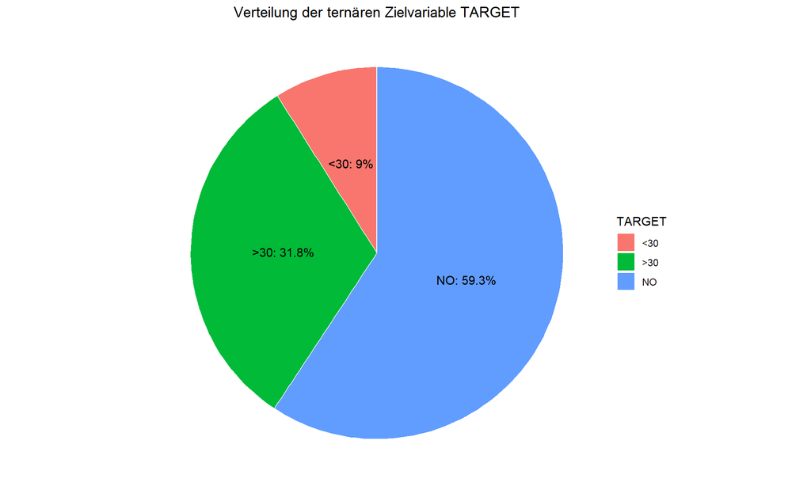

```r
ddt_summary <- diabetic_data_ter %>%
  dplyr::count(TARGET) %>%
  dplyr::mutate(
    anteil = n / sum(n),
    text_label = paste0(TARGET, ": ", round(100 * anteil, 1), "%")
  )

ggplot(ddt_summary, aes(x = "", y = anteil, fill = TARGET)) +
  geom_bar(stat = "identity", width = 1, color = "white") +
  coord_polar("y", start = 0) +
  geom_text(aes(label = text_label), position = position_stack(vjust = 0.5)) +
  labs(title = "Verteilung der ternären Zielvariable TARGET") +
  theme_void() +
  theme(plot.title = element_text(hjust = 0.5))
```

Erzeugung des Datensatz *diabetic_data_bin* aus dem Datensatz *diabetic_data_ter* wie vorgegeben:

```r
diabetic_data_bin <- diabetic_data_ter %>%
  dplyr::filter(!(TARGET == ">30")) %>%
  dplyr::mutate(TARGET = ifelse(TARGET == "<30", 1, 0)) %>%
  dplyr::mutate(TARGET = as.factor(TARGET)) %>%
  droplevels()
```

Darstellung der binären Zielvariable *TARGET* in einem Tortendiagramm:

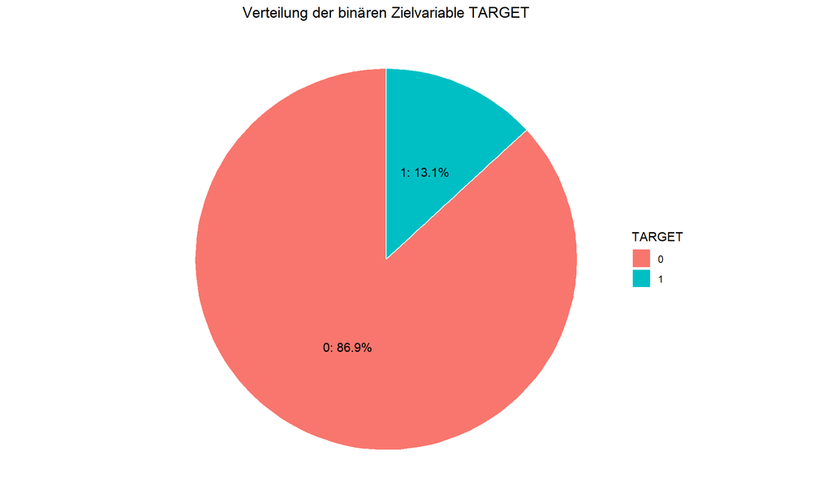

```r
ddb_summary <- diabetic_data_bin %>%
  dplyr::count(TARGET) %>%
  dplyr::mutate(
    anteil = n / sum(n),
    text_label = paste0(TARGET, ": ", round(100 * anteil, 1), "%")
  )

ggplot(ddb_summary, aes(x = "", y = anteil, fill = TARGET)) +
  geom_bar(stat = "identity", width = 1, color = "white") +
  coord_polar("y", start = 0) +
  geom_text(aes(label = text_label), position = position_stack(vjust = 0.5)) +
  labs(title = "Verteilung der binären Zielvariable TARGET") +
  theme_void() +
  theme(plot.title = element_text(hjust = 0.5))
```

Das Tortendiagramm zeigt, dass ein deutliches Ungleichgewicht / eine Imbalance in den Daten zugunsten der Ausprägung 0 vorliegt. Knapp 87% der Datensätze haben einen TARGET-Wert von 0, lediglich 13% haben einen TARGET-Wert von 1.

Aufgrund der vorliegenden Imbalance ist die Wahl des verwendeten Gütemaßes ein entscheidendes Kriterium: wird beispielsweise Accuracy (Genauigkeit) als Gütemaß herangezogen, so erreicht ein Modell mit konstanter Prognose 0 eine Genauigkeit von 87%.

Es wäre möglich bzw. zu überlegen, ob die Imbalance in den nachfolgenden Modellierungen bereits in den Parametern berücksichtigt werden sollte, da in vielen Modellen eine Gewichtung der einzelnen Beobachtungen als Parameter möglich ist.

Ausgabe der ersten 10 Zeilen des ausbereiteten Datensatzes und Speicherung in der Datei *diabetic_data_bin.csv* (wird im zweiten Aufgabenteil Python verwendet).

```r
head(diabetic_data_bin, 10)
```

```
##               race gender     age weight admission_type_id
## 1        Caucasian Female [50-60)      ?                 2
## 2        Caucasian Female [50-60)      ?                 3
## 3        Caucasian Female [80-90)      ?                 1
## 4        Caucasian Female [80-90)      ?                 1
## 5  AfricanAmerican Female [30-40)      ?                 1
## 6        Caucasian Female [60-70)      ?                 3
## 7        Caucasian Female [70-80)      ?                 2
## 8        Caucasian   Male [60-70)      ?                 2
## 9        Caucasian Female [70-80)      ?                 3
## 10       Caucasian Female [80-90)      ?                 1
##    discharge_disposition_id admission_source_id time_in_hospital payer_code
## 1                         1                   1                8          ?
## 2                         1                   1                2          ?
## 3                         3                   7                4         MC
```

[output cut: 95 more lines]

```r
write.csv2(x = diabetic_data_bin, file = "data/diabetic_data_bin.csv", row.names = FALSE)
```

# 3 R2: Explorative Datenanalyse und Visualisierung

## 3.1 a) 3 Overview

Die folgende Übersicht aus der Funktion *summary()* zeigt, dass viele Variablen nach der Bereinigung nur mehr eine Ausprägung haben. Diese tragen keinen Mehrwert in den anschließenden Modellbildungen bei.

```r
summary(diabetic_data_bin)
```

```
##               race          gender           age              weight
##  ?              : 1483   Female:25152   [70-80):11623   ?        :46283
##  AfricanAmerican: 8757   Male  :22599   [60-70):10736   [75-100) :  589
##  Asian          :  381                  [50-60): 8615   [50-75)  :  428
##  Caucasian      :35203                  [80-90): 7242   [100-125):  304
##  Hispanic       : 1088                  [40-50): 4885   [125-150):   70
##  Other          :  839                  [30-40): 2003   [25-50)  :   43
##                                         (Other): 2647   (Other)  :   34
##  admission_type_id discharge_disposition_id admission_source_id
##  1:24036           1      :30258            7      :24540
##  2: 8731           3      : 6029            1      :15312
##  3:10056           6      : 5189            17     : 3090
##  5: 2047           18     : 1921            4      : 2021
##  6: 2641           2      : 1101            6      : 1479
##  7:   18           22     : 1073            2      :  673
##  8:  222           (Other): 2180            (Other):  636
##  time_in_hospital   payer_code                 medical_specialty
##  Min.   : 1.000   ?      :20378   ?                     :22642
##  1st Qu.: 2.000   MC     :13115   InternalMedicine      : 7341
##  Median : 3.000   HM     : 2821   Family/GeneralPractice: 3312
##  Mean   : 4.205   BC     : 2601   Emergency/Trauma      : 2875
##  3rd Qu.: 6.000   SP     : 2259   Cardiology            : 2811
##  Max.   :14.000   MD     : 1522   Surgery-General       : 1528
##                   (Other): 5055   (Other)               : 7242
##  num_lab_procedures num_procedures  num_medications number_outpatient
##  Min.   :  1.00     Min.   :0.000   Min.   : 1.00   Min.   : 0.000
##  1st Qu.: 30.00     1st Qu.:0.000   1st Qu.:10.00   1st Qu.: 0.000
##  Median : 44.00     Median :1.000   Median :14.00   Median : 0.000
##  Mean   : 42.36     Mean   :1.458   Mean   :15.56   Mean   : 0.233
##  3rd Qu.: 56.00     3rd Qu.:2.000   3rd Qu.:20.00   3rd Qu.: 0.000
##  Max.   :132.00     Max.   :6.000   Max.   :81.00   Max.   :36.000
##
##  number_emergency   number_inpatient      diag_1          diag_2
##  Min.   : 0.00000   Min.   : 0.0000   414    : 3641   250    : 3748
##  1st Qu.: 0.00000   1st Qu.: 0.0000   428    : 2219   276    : 3047
##  Median : 0.00000   Median : 0.0000   786    : 2063   428    : 2589
##  Mean   : 0.08157   Mean   : 0.1383   410    : 2006   401    : 2309
##  3rd Qu.: 0.00000   3rd Qu.: 0.0000   486    : 1488   427    : 2283
##  Max.   :37.00000   Max.   :12.0000   715    : 1418   599    : 1495
##                                       (Other):34916   (Other):32280
```

[output cut: 49 more lines]

```
##  Ch:21017   No :12040   0:41474   Circulatory:14395   Circulatory  :14079
##  No:26734   Yes:35711   1: 6277   Other      : 8104   Other        :12432
##                                   Respiratory: 6032   Diabetes     : 7141
##                                   Digestive  : 4229   Respiratory  : 4461
##                                   Diabetes   : 3895   Genitourinary: 3612
##                                   Injury     : 3374   Digestive    : 1830
##                                   (Other)    : 7722   (Other)      : 4196
##         group_diag_3
##  Circulatory  :13433
##  Other        :13108
##  Diabetes     : 9444
##  Respiratory  : 3017
##  Genitourinary: 2676
##  Digestive    : 1644
##  (Other)      : 4429
```

Die Übersicht zeigt allerdings für viele kategoriellen Merkmale nicht, ob die in *Abschnitt 2.6 f)* durchgeführte Bereinigung (mindestens 10 Beobachtungen pro Ausprägung) erfolgreich war, da die einzelnen Merkmale nach der Anzahl der Ausprägungen absteigend geordnet und nur die sechs häufigsten Ausprägungen einzeln aufgelistet sind. Die restlichen Merkmale sind in der Gruppe *(Other)* zusammengefasst - siehe beispielsweise das Merkmal *age*, in der nur die häufigsten sechs Altersgruppen zu sehen sind und die restlichen Altersgruppen mit insgesamt 2.647 Beobachtungen, zusammengefasst wurden. Deshalb wurde die Analyse (mindestens 10 Beobachtungen pro Ausprägung) bereits im *Abschnitt 2.6 f)* durchgeführt.

```r
glimpse(diabetic_data_bin)
```

```
## Rows: 47,751
## Columns: 51
## $ race                     <fct> Caucasian, Caucasian, Caucasian, Caucasian, A…
## $ gender                   <fct> Female, Female, Female, Female, Female, Femal…
## $ age                      <fct> [50-60), [50-60), [80-90), [80-90), [30-40), …
## $ weight                   <fct> ?, ?, ?, ?, ?, ?, ?, ?, ?, ?, ?, ?, ?, ?, ?, …
## $ admission_type_id        <fct> 2, 3, 1, 1, 1, 3, 2, 2, 3, 1, 1, 1, 3, 3, 1, …
## $ discharge_disposition_id <fct> 1, 1, 3, 1, 1, 1, 3, 1, 1, 3, 1, 1, 5, 1, 1, …
## $ admission_source_id      <fct> 1, 1, 7, 7, 7, 1, 1, 1, 1, 7, 7, 7, 1, 1, 7, …
## $ time_in_hospital         <int> 8, 2, 4, 3, 5, 9, 12, 8, 1, 7, 4, 1, 4, 6, 4,…
## $ payer_code               <fct> ?, ?, MC, ?, ?, ?, ?, ?, ?, ?, ?, ?, ?, ?, ?,…
## $ medical_specialty        <fct> Cardiology, Surgery-Neuro, InternalMedicine, …
## $ num_lab_procedures       <int> 77, 49, 68, 46, 49, 52, 47, 57, 31, 77, 47, 3…
## $ num_procedures           <int> 6, 1, 2, 0, 0, 1, 2, 6, 1, 0, 4, 5, 2, 2, 3, …
## $ num_medications          <int> 33, 11, 23, 20, 5, 16, 18, 31, 9, 12, 16, 13,…
```

[output cut: 38 more lines]

Der Datensatz *diabetic_data_bin* hat 51 Merkmale (inklusive der Variable *TARGET*), 47.751 Beobachtungen und enthält nur Merkmale mit diskreter Ausprägung (kategorielle Merkmale oder Merkmale mit Integer-Werten).

Für spätere Analysen wird eine Tabelle *merkmale_info* erstellt, die Informationen zum Typ und der Anzahl von verschiedenen Ausprägungen der einzelnen Merkmalen enthält.

```r
merkmale_info <- lapply(names(diabetic_data_bin), function(spaltenname) {
  spalte <- diabetic_data_bin[[spaltenname]]
  list(
    Merkmal = spaltenname,
    Typ = class(spalte),
    Anzahl = length(unique(spalte))
  )
})

merkmale_info <- dplyr::bind_rows(merkmale_info) %>%
  dplyr::arrange(Typ, Anzahl) %>%
  data.frame()

merkmale_info
```

```
##                     Merkmal     Typ Anzahl
## 1             acetohexamide  factor      1
## 2              troglitazone  factor      1
## 3                   examide  factor      1
## 4               citoglipton  factor      1
## 5       glipizide.metformin  factor      1
## 6  glimepiride.pioglitazone  factor      1
## 7   metformin.rosiglitazone  factor      1
## 8    metformin.pioglitazone  factor      1
## 9                    gender  factor      2
## 10           chlorpropamide  factor      2
## 11              tolbutamide  factor      2
## 12                 miglitol  factor      2
## 13               tolazamide  factor      2
## 14      glyburide.metformin  factor      2
```

[output cut: 37 more lines]

Die Tabelle zeigt, dass 43 kategorielle Merkmale und 8 numerische Merkmale im Datensatz vorhanden sind.

## 3.2 b) 4 Individual feature visualisations

Die bereits erwähnt, zeigt die Analyse von *merkmale_info* dass es nur zwei Arten von Merkmaltyp gibt: kategorielle bzw. numerische.

Aus der obigen Analyse folgt die Einteilung der Merkmale in 5 Gruppen, wobei die weitaus größere kategorielle Gruppe in *eine Ausprägung*, *binäres Merkmal*, *mittler Anzahl von Ausprägungen* und *hohe Anzahl von Ausprägungen* unterteilt wird:

- Kategorielle (Faktor-) Variablen mit einer Ausprägung (Gruppe 1)
- Kategorielle (Faktor-) Variablen mit zwei Ausprägungen (Gruppe 2)
- Kategorielle (Faktor-) Variablen mit mehr als zwei und weniger als 10 Ausprägungen (Gruppe 3)
- Kategorielle (Faktor-) Variablen mit 10 oder mehr Ausprägungen (Gruppe 4)
- Integer-Variablen (Gruppe 5)

Für die weitere Verwendung wird die oben gewählt Gruppierung als zusätzliche Spalte in die Tabelle eingetragen *merkmale_info* eingetragen, wobei die Variablen *TARGET*, *diag_1*, *diag_2* und *diag_3* auf die Gruppe “Unbekannt” gesetzt werden.

```r
merkmale_info <- merkmale_info %>%
  dplyr::mutate(Gruppe = dplyr::case_when(
    Merkmal %in% c("TARGET", "diag_1", "diag_2", "diag_3") ~ "Unbekannt",
    Typ == "factor" & Anzahl == 1 ~ "Gruppe_1",
    Typ == "factor" & Anzahl == 2 ~ "Gruppe_2",
    Typ == "factor" & Anzahl >= 3 & Anzahl < 10 ~ "Gruppe_3",
    Typ == "factor" & Anzahl >= 10 ~ "Gruppe_4",
    Typ == "integer" ~ "Gruppe_5",
    .default = "Unbekannt"
  ))
```

Die Funktion *generate_plot* dient zum Erstellen der nachfolgenden Plots.

```r
generate_plot <- function(data_in, merkmale, plot_type = 1, nr_col = 4, use_log = 1, angle = 0) {
  # plot_type:
  #    1 ... Bar-Plot
  #    2 ... Bar-Plot mit factor-Umwandlung (für Integer-Variablen)
  #    3 ... Kerndichteschätzer für kategorielle Merkmale
  #    4 ... Kerndichteschätzer für Integer-Variablen

  # use_log:
  #    0 ... y-Achse wird linear dargestellt
  #    1 ... y-Achse wird logarithmisch dargestellt

  # angle:
  #    0 ... Die Beschriftung der x-Achse wird nicht gedreht
  #    1 ... Die Beschriftung der x-Achse wird um 90 Grad gedreht

  plot_list <- list()

  for (Merkmal in merkmale) {
    if (is.factor(data_in[,Merkmal])) {
      if (nr_col > 1 & length(levels(data_in[,Merkmal])) > 5 & max(nchar(levels(data_in[,Merkmal]))) > 10) {
        angle = 1
      }
    }

    if (plot_type == 1) {
      plot_list[[Merkmal]] <- ggplot(data_in, aes(x = !!rlang::sym(Merkmal), fill = !!rlang::sym(Merkmal))) +
        geom_bar()
    } else if (plot_type == 2) {
      plot_list[[Merkmal]] <- ggplot(data_in, aes(x = !!rlang::sym(Merkmal), fill = as.factor(!!rlang::sym(Merkmal)))) +
        geom_bar()
    } else if (plot_type == 3) {
      tmp <- as.character(levels(data_in[,Merkmal]))
      data_in[,Merkmal] <- as.numeric(data_in[,Merkmal])
      plot_list[[Merkmal]] <- ggplot(data_in, aes(x = !!rlang::sym(Merkmal))) +
        geom_density() +
        scale_x_continuous(breaks = 1:length(tmp), labels = tmp)
    } else if (plot_type == 4) {
      plot_list[[Merkmal]] <- ggplot(data_in, aes(x = !!rlang::sym(Merkmal))) +
        geom_density()
    }

    plot_list[[Merkmal]] <- plot_list[[Merkmal]] +
      theme(legend.position = "none",
            panel.background = element_rect(fill = "white", color = NA),
            plot.background = element_rect(fill = "white", color = NA))

    if (angle == 1) {
      plot_list[[Merkmal]] <- plot_list[[Merkmal]] +
        theme(axis.text.x = element_text(angle = 90))
    }

    if (use_log == 1) {
      plot_list[[Merkmal]] <- plot_list[[Merkmal]] +
        scale_y_log10() +
        ylab("count (log)")
    }
  }

  number_plots <- length(plot_list)
  nr_row <- ceiling(number_plots/nr_col)
  layout <- matrix(1:(nr_row*nr_col), nr_row, nr_col, byrow = TRUE)
  p <- multiplot(plotlist = plot_list, layout=layout)

  return(p)
}
```

Bemerkung zu den folgenden Grafiken:

- Wie in der Aufgabenstellung gefordert, wird die aus SWoF übernommene Funktion *multiplot* für die Darstellung der Grafiken verwendet. Damit die einzelnen Ausprägungen der Merkmale lesbar bleiben, wird die einfache Darstellungs-Form pro Merkmal aus SWoF übernommen (d.h. nur Beschriftung der x- und y-Achse, aber kein Titel, … pro Grafik).
- Damit die einzelnen Grafiken nicht für jedes Merkmal einzeln definiert werden müssen, wird die oben definierte Funktion *generate_plot* verwendet. Die aus SWoF übernommene Funktion *multiplot* wird darin aufgerufen.
- Für die Darstellung der jeweiligen Merkmale wurde ein Histogramm UND Kerndichteschätzerplot gefordert. Für beispielsweise binäre kategorielle Merkmale ist der Erkenntnissgewinn aus dem Kerndichteschätzer gering, der Vollständigkeitshalber werden sie gemacht.
- Die Histrogramme werden in Form eines Bar-Plots dargestellt. In *R* wird zwischen den Funktionen *geom_bar* und *geom_histogram* unterschieden, *geom_histogram* ist allerdings nur für stetige Variablen geeignet.

**Generelle Bemerkung**: Im Gegensatz zur Vorlage SWoF kommen im vorliegenden Datensatz keine numerischen (float) Werte vor, d.h. die Abschnitte 4.7 und 4.8 sind nicht anwendbar. Falls die in diesen beiden Abschnitten betrachteten Histogramme die Kerndichteschätzer sein sollten, wurde die Aufgabenstellung von mir leider missverstanden und ich bitte vielmals um Entschuldigung - in der weiteren Ausarbeitung wurden eigene Kerndichteschätzer berechnet.

**Einzelne Ausprägung (Gruppe 1)**

Der Plot dieser Gruppe ist wenig aussagekräftig, er wird allerdings aus Vollständigkeitsgründen gemacht.

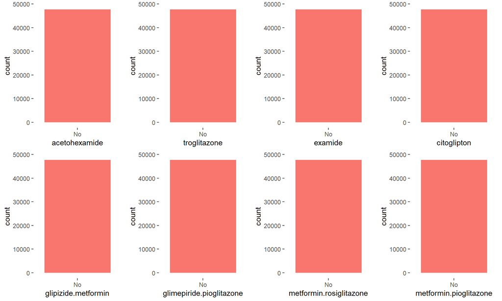

```r
plot_data <- diabetic_data_bin %>%
  dplyr::select(
    dplyr::all_of(merkmale_info %>%
                    dplyr::filter(Gruppe == "Gruppe_1") %>%
                    dplyr::pull(Merkmal)))
tmp <- generate_plot(plot_data, merkmale = colnames(plot_data), plot_type = 1, nr_col = 4, use_log = 0)
```

**Binäre kategorielle Variablen (Gruppe 2)**

Histogramm

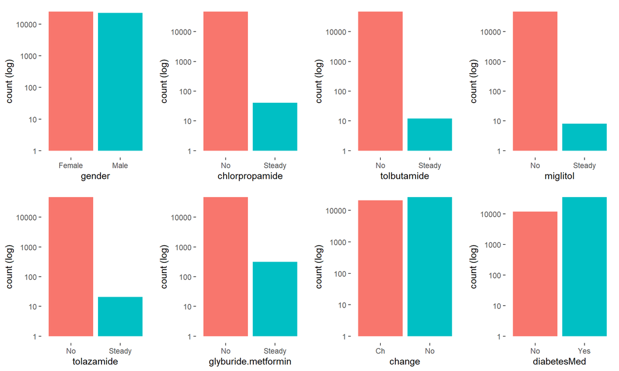

```r
plot_data <- diabetic_data_bin %>%
  dplyr::select(
    dplyr::all_of(merkmale_info %>%
                    dplyr::filter(Gruppe == "Gruppe_2") %>%
                    dplyr::pull(Merkmal)))

tmp <- generate_plot(plot_data, merkmale = colnames(plot_data), plot_type = 1, nr_col = 4, use_log = 1)
```

Die Darstellung der Histogramme erfolgt mit logarithmierter y-Achse und zeigt, dass viele der binären kategoriellen Merkmale sehr unbalanciert sind und bei vielen die Ausprägung *No* überwiegt. Für einige der Variablen, wie beispielsweise *tolbutamide* und *miglitol* sollte geprüft werden, ob diese in der Modellierung sinnvoll verwendet werden können, da die Ausprägung *Steady* lediglich 10 Mal beobachtet wurde.

Kerndichteschätzer

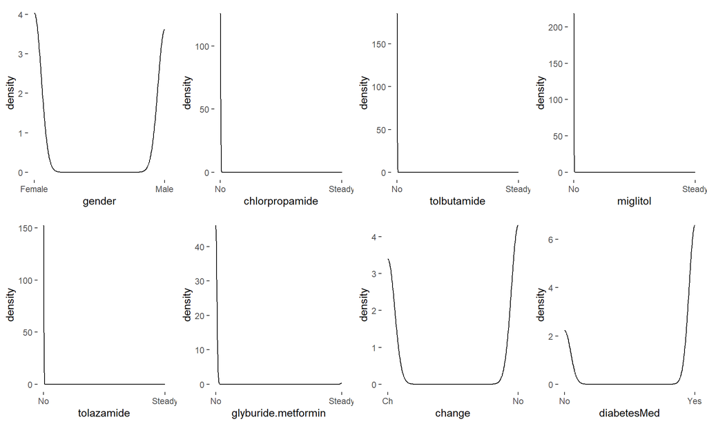

```r
tmp <- generate_plot(plot_data, merkmale = colnames(plot_data), plot_type = 3, nr_col = 4, use_log = 0)
```

Die Kerndichteschätzer zeigen den aufgrund der Histogramme “erwarteten” Verlauf, wobei bei den unbalancierten Merkmalen fast die gesamte Dichte auf der Ausprägung *No* liegt.

**Kategorielle Variablen mit mehr als zwei und weniger als 10 Ausprägungen (Gruppe 3)**

Histogramm

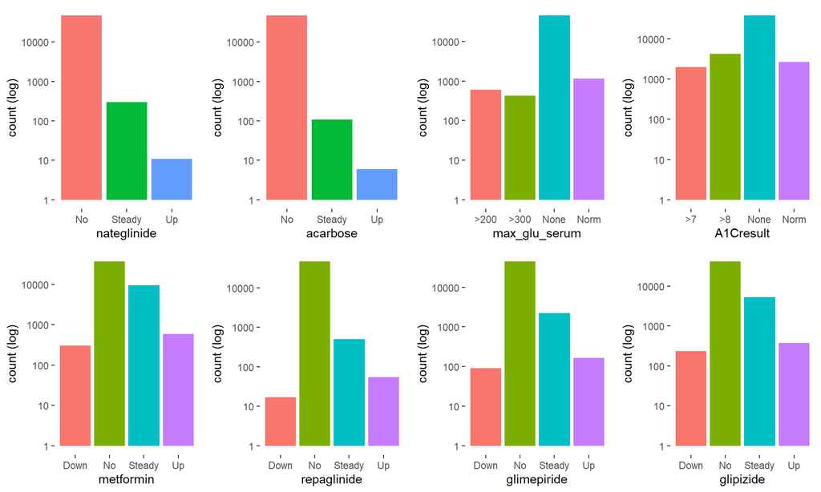

```r
plot_data <- diabetic_data_bin %>%
  dplyr::select(
    dplyr::all_of(merkmale_info %>%
                    dplyr::filter(Gruppe == "Gruppe_3") %>%
                    dplyr::pull(Merkmal)))

tmp <- generate_plot(plot_data, merkmale = colnames(plot_data)[1:8], plot_type = 1, nr_col = 4, use_log = 1)
```

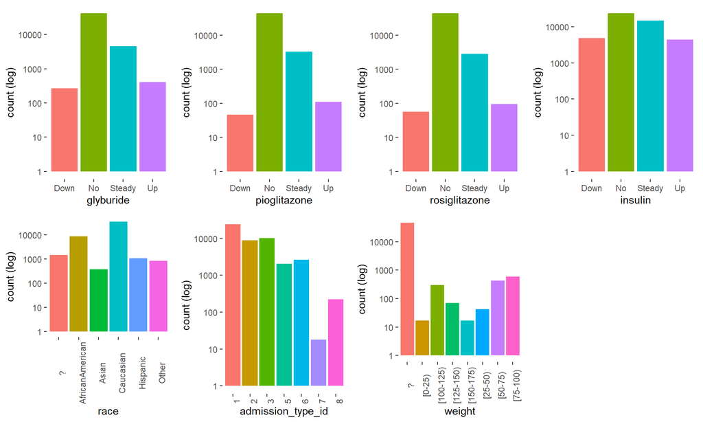

```r
tmp <- generate_plot(plot_data, merkmale = colnames(plot_data)[9:15], plot_type = 1, nr_col = 4, use_log = 1)
```

Kerndichteschätzer

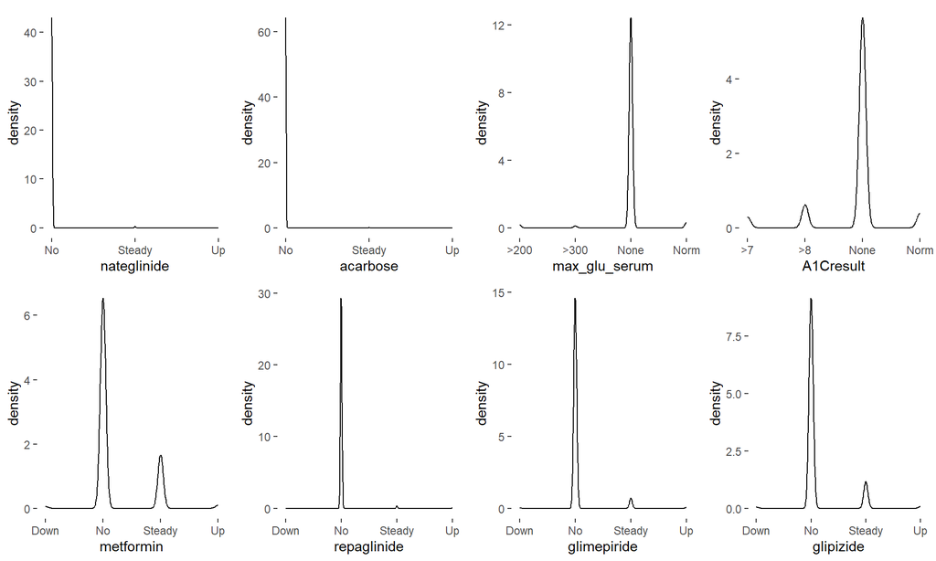

```r
tmp <- generate_plot(plot_data, merkmale = colnames(plot_data)[1:8], plot_type = 3, nr_col = 4, use_log = 0)
```

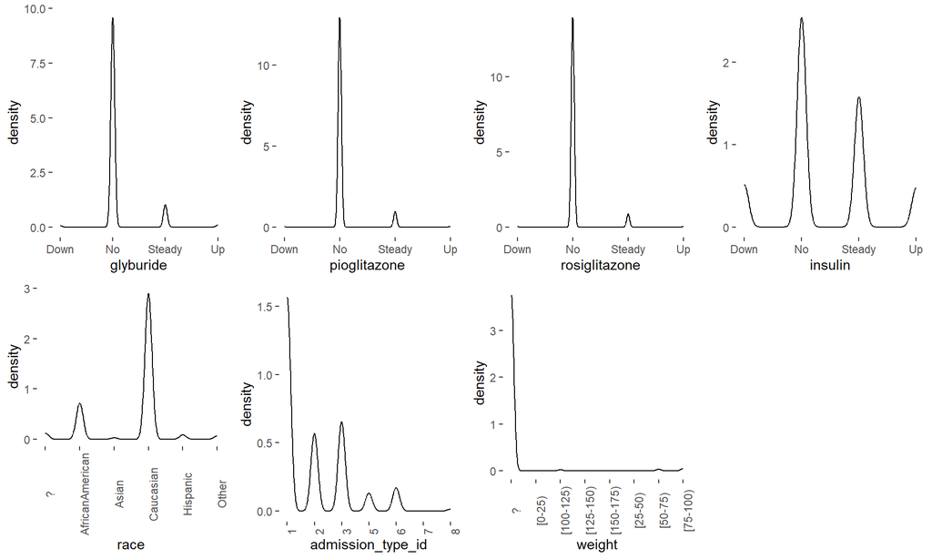

```r
tmp <- generate_plot(plot_data, merkmale = colnames(plot_data)[9:15], plot_type = 3, nr_col = 4, use_log = 0)
```

**Kategorielle Variablen mit 10 oder mehr Ausprägungen (Gruppe 4)**

Histogramm

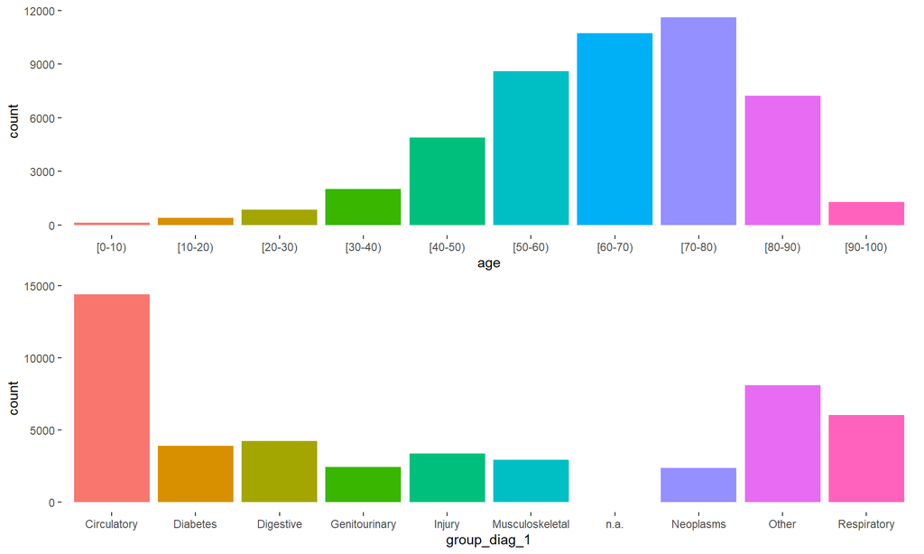

```r
plot_data <- diabetic_data_bin %>%
  dplyr::select(
    dplyr::all_of(merkmale_info %>%
                    dplyr::filter(Gruppe == "Gruppe_4") %>%
                    dplyr::pull(Merkmal)))

tmp <- generate_plot(plot_data, merkmale = colnames(plot_data)[1:2], plot_type = 1, nr_col = 1, use_log = 0)
```

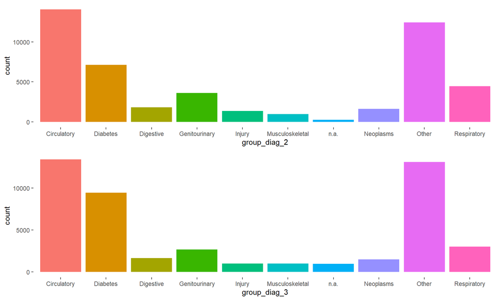

```r
tmp <- generate_plot(plot_data, merkmale = colnames(plot_data)[3:4], plot_type = 1, nr_col = 1, use_log = 0)
```

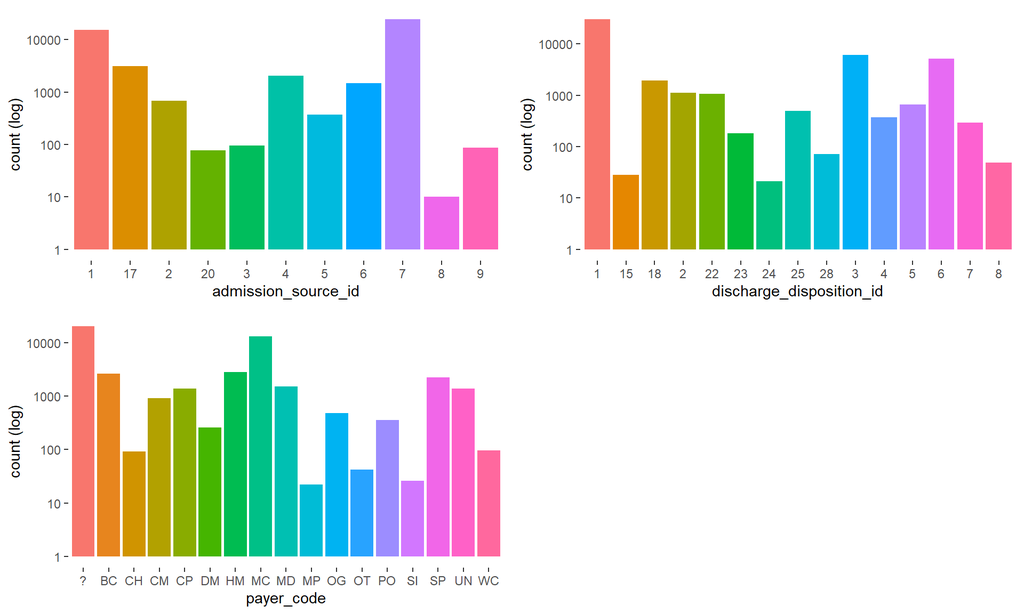

```r
tmp <- generate_plot(plot_data, merkmale = colnames(plot_data)[5:7], plot_type = 1, nr_col = 2, use_log = 1)
```

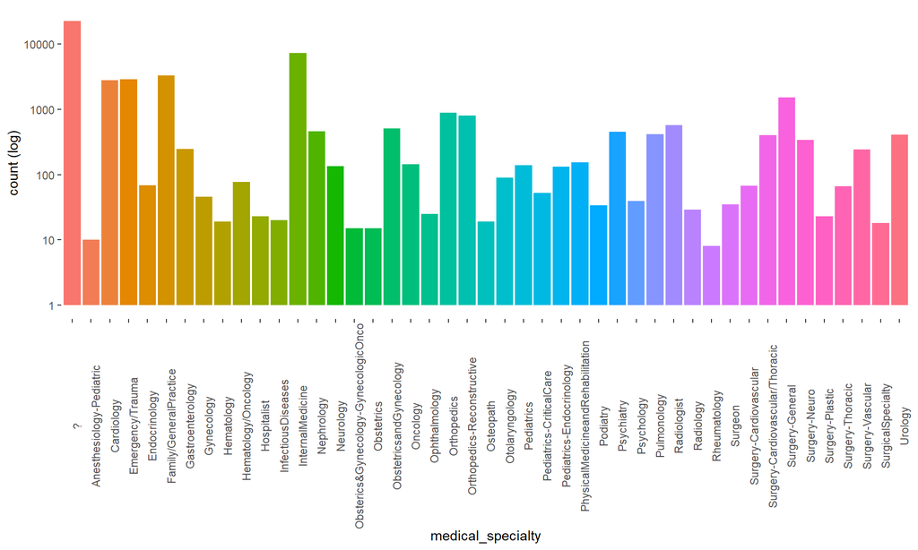

```r
tmp <- generate_plot(plot_data, merkmale = colnames(plot_data)[8], plot_type = 1, nr_col = 1, use_log = 1, angle = 1)
```

Die Darstellung des Histogrammes der unteren 4 Merkmale erfolgt mit logarithmierter y-Achse, die restlichen Histogramme haben eine lineare y-Achse. Im Merkmal *discharge_disposition_id* ist die Ausprägung *1* dominierend.

Die Ausprägungen “n.a.” in den drei Merkmalen *group_diag_1*, *group_diag_2* und *group_diag_3* sind keine Datenfehler im Sinne von fehlenden Werten im Data-Frame, sondern kommen aus den ursprünglichen Merkmalen *diag_1*, *diag_2* bzw. *diag_3*, die Fragezeichen (?) enthalten. Diese Fragezeichen entsprechen im *icd9*-Datensatz einem “n.a.”.

Kerndichteschätzer

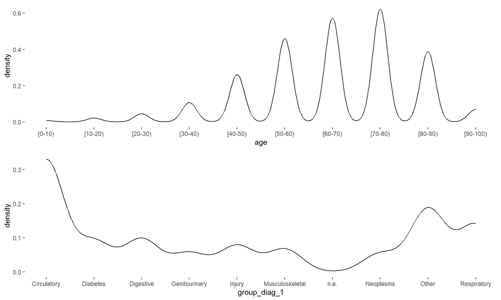

```r
tmp <- generate_plot(plot_data, merkmale = colnames(plot_data)[1:2], plot_type = 3, nr_col = 1, use_log = 0)
```

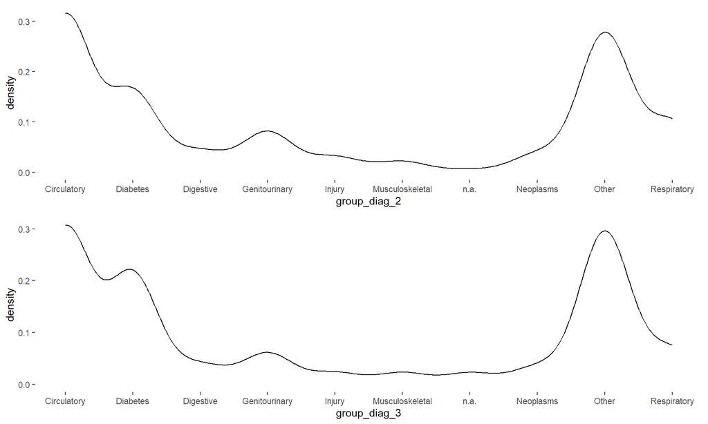

```r
tmp <- generate_plot(plot_data, merkmale = colnames(plot_data)[3:4], plot_type = 3, nr_col = 1, use_log = 0)
```

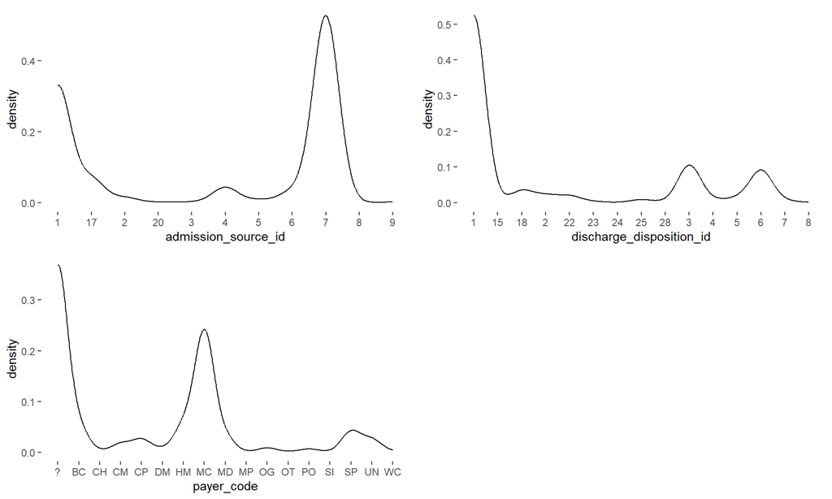

```r
tmp <- generate_plot(plot_data, merkmale = colnames(plot_data)[5:7], plot_type = 3, nr_col = 2, use_log = 0)
```

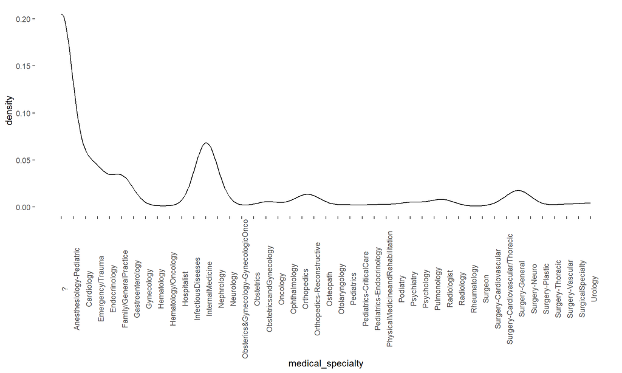

```r
tmp <- generate_plot(plot_data, merkmale = colnames(plot_data)[8], plot_type = 3, nr_col = 1, use_log = 0, angle = 1)
```

Die Kerndichteschätzer zeigen den aufgrund der Histogramme “erwarteten” Verlauf.

**Integer-Variablen (Gruppe 5)**

Histogramm

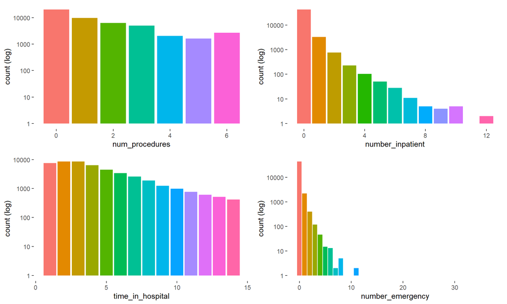

```r
plot_data <- diabetic_data_bin %>%
  dplyr::select(
    dplyr::all_of(merkmale_info %>%
                    dplyr::filter(Gruppe == "Gruppe_5") %>%
                    dplyr::pull(Merkmal)))

tmp <- generate_plot(plot_data, merkmale = colnames(plot_data)[1:4], plot_type = 2, nr_col = 2, use_log = 1)
```

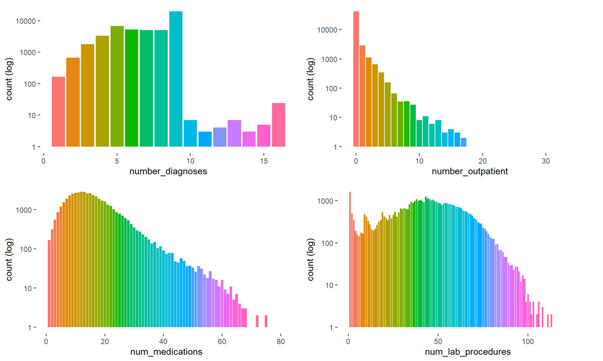

```r
tmp <- generate_plot(plot_data, merkmale = colnames(plot_data)[5:8], plot_type = 2, nr_col = 2, use_log = 1)
```

Die Darstellung der Histogramme erfolgt mit logarithmierter y-Achse und zeigen in den zwei Merkmalen *number_emergency* und *number_outpatient* Ausreißer (wenige Beobachtungen mit einer deutlich höherer Zahl als der Rest).

Kerndichteschätzer

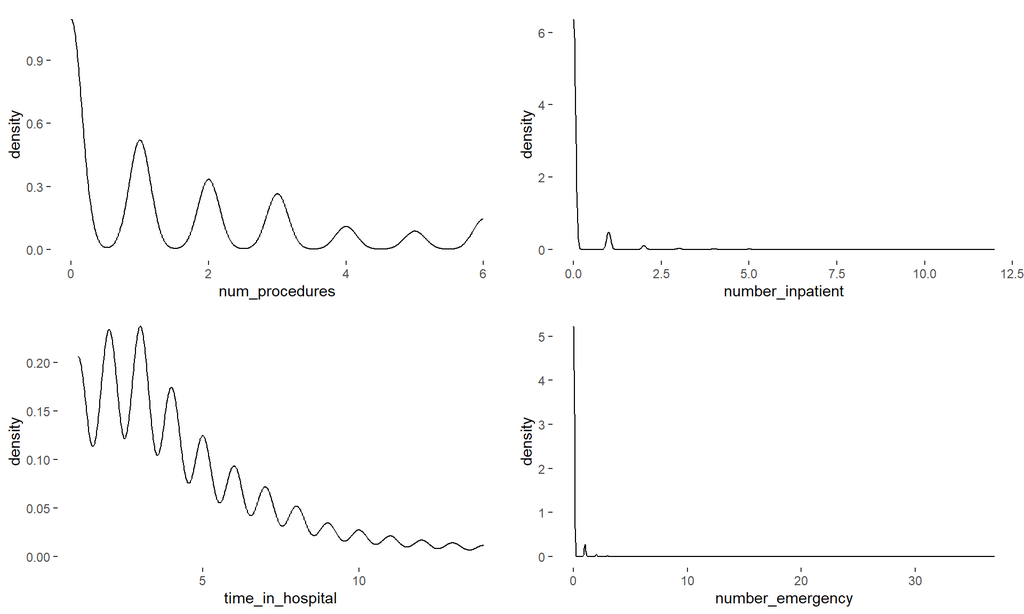

```r
tmp <- generate_plot(plot_data, merkmale = colnames(plot_data)[1:4], plot_type = 4, nr_col = 2, use_log = 0)
```

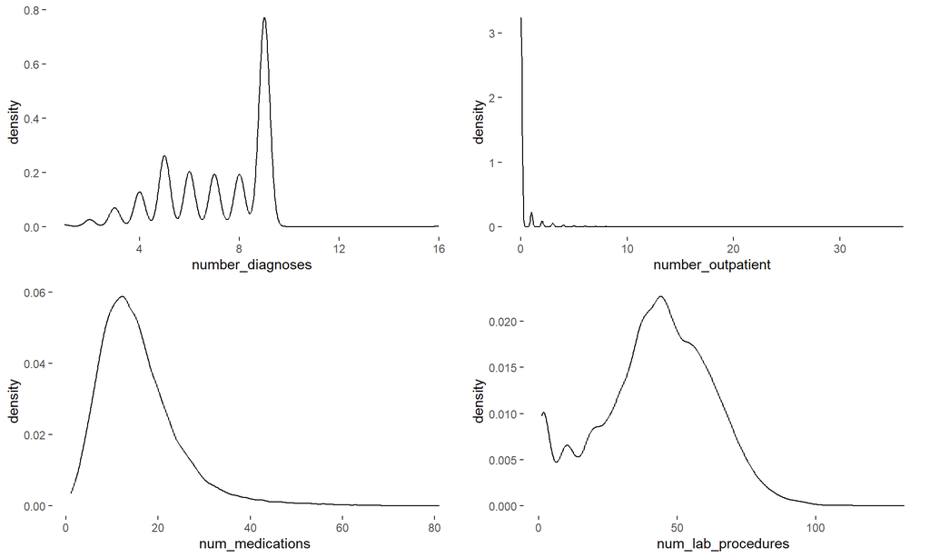

```r
tmp <- generate_plot(plot_data, merkmale = colnames(plot_data)[5:8], plot_type = 4, nr_col = 2, use_log = 0)
```

Die Kerndichteschätzer zeigen den aufgrund der Histogramme “erwarteten” Verlauf.

**TARGET-Variable**

Im Folgenden wird zur Vollständigkeit die Verteilung der TARGET-Variable dargestellt und zeigt nochmals die bereits aus dem Tortendiagramm bekannte deutliche Imbalance zugunsten der Ausprägung “0”.

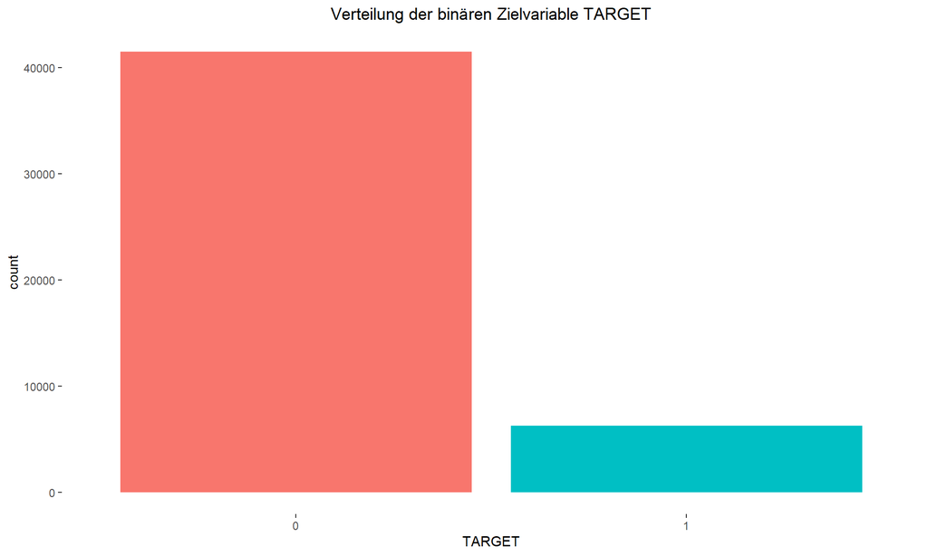

```r
diabetic_data_bin %>%
  ggplot(aes(TARGET, fill = TARGET)) +
  geom_bar() +
  theme(legend.position = "none",
        plot.title = element_text(hjust = 0.5),
        panel.background = element_rect(fill = "white", color = NA),
        plot.background = element_rect(fill = "white", color = NA)) +
  labs(title = "Verteilung der binären Zielvariable TARGET")
```

## 3.3 c) 5 Claim rates for individual features

**Bemerkung**: Die nachfolgenden Aussagen zu den einzelnen Merkmalen basieren auf folgenden Überlegungen:

- Wenn für ein Merkmal die Durchschnittswerte der Zielvariable (Wiedereinweisungsquote) stark variieren, könnte dies ein Hinweis sein, dass dieses Merkmal signifikant für die Erklärung der Zielvariable ist. Ist der Durschnittswert der Zielvariable für alle Ausprägungen fast gleich, könnte das ein Hinweis sein, dass das entsprechende Merkmal wenig zur Erklärung der Zielvariable beiträgt (nicht signifikant ist)
- Wenn ein Merkmal eine hohe Streuung der Zielvariable innerhalb einer Ausprägung hat, kann das ein Hinweis sein, dass dieses Merkmal nicht signifikant für die Prognose der Zielvariable ist, da keine klare Beziehung zur Zielvariable vorliegt. Bei hoher Streuung ist es schwierig, präzise Prognosen zu treffen.
- Eine niedrige Streuung in den einzelnen Ausprägungen eines Merkmals bei gleichzeitig hoher Differenz im Durchschnittswert der Zielvariable weist tendenziell auf eine hohe Signifikanz des Merkmals zur Prognose der Zielvariable hin.
- Die obenstehenden Aussagen beziehen sich nur auf die einzelnen Merkmale selbst. Erfüllt ein Merkmal alle Voraussetzungen für hohe Signifikanz aber hat eine hohe Korrelation mit anderen Merkmalen, könnte es trotzdem redundant und wenig signifikant sein.

Die Funktion *generate_plot_claims* dient zur Erzeugung der nachfolgenden Plots.

```r
generate_plot_claims <- function(data_in, merkmale, plot_type = 1, nr_col = 4, angle = 0) {
  # plot_type:
  #   1 ... Bar-Plot
  #   2 ... Scatter-Plot

  # angle:
  #    0 ... Die Beschriftung der x-Achse wird nicht gedreht
  #    1 ... Die Beschriftung der x-Achse wird um 90 Grad gedreht

  plot_list <- list()

  merkmale_loop <- merkmale[!(merkmale == "TARGET")]

  for (Merkmal in merkmale_loop) {
    if (is.factor(data_in[,Merkmal])) {
      if (nr_col > 1 & length(levels(data_in[,Merkmal])) > 5 & max(nchar(levels(data_in[,Merkmal]))) > 10) {
        angle = 1
      }
    }

    plot_list[[Merkmal]] <- data_in %>%
      dplyr::group_by(!!rlang::sym(Merkmal), TARGET) %>%
      dplyr::count() %>%
      tidyr::pivot_wider(names_from = TARGET, values_from = n, values_fill = 0) %>%
      dplyr::mutate(frac_claim = `1`/(`1`+`0`)*100,
                    lwr = get_binCI(`1`,(`1`+`0`))[[1]]*100,
                    upr = get_binCI(`1`,(`1`+`0`))[[2]]*100) %>%
      ggplot(aes(!!rlang::sym(Merkmal), frac_claim, fill = !!rlang::sym(Merkmal))) +
      geom_errorbar(aes(ymin = lwr, ymax = upr), width = 0.5, linewidth = 0.7, color = "gray30") +
      theme(legend.position = "none") +
      labs(y = "Claims [%]")

    if (plot_type == 1) {
      plot_list[[Merkmal]] <- plot_list[[Merkmal]] +
        geom_col()
    } else if (plot_type == 2) {
      plot_list[[Merkmal]] <- plot_list[[Merkmal]] +
        geom_point(color = "orange")
    }

    plot_list[[Merkmal]] <- plot_list[[Merkmal]] +
      theme(legend.position = "none",
            panel.background = element_rect(fill = "white", color = NA),
            plot.background = element_rect(fill = "white", color = NA))

    if (angle == 1) {
      plot_list[[Merkmal]] <- plot_list[[Merkmal]] +
        theme(axis.text.x = element_text(angle = 90))
    }
  }

  number_plots <- length(plot_list)
  nr_row <- ceiling(number_plots/nr_col)
  layout <- matrix(1:(nr_row*nr_col), nr_row, nr_col, byrow = TRUE)
  p <- multiplot(plotlist = plot_list, layout=layout)

  return(p)
}
```

**Einzelne Ausprägung (Gruppe 1)**

Der Plot dieser Gruppe ist wenig aussagekräftig, er wird allerdings aus Vollständigkeitsgründen gemacht.

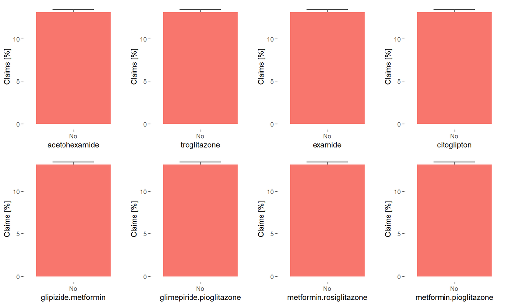

```r
plot_data <- diabetic_data_bin %>%
  dplyr::select(
    dplyr::all_of(merkmale_info %>%
                    dplyr::filter(Gruppe == "Gruppe_1" | Merkmal == "TARGET") %>%
                    dplyr::pull(Merkmal)))
merkmale <- colnames(plot_data)
merkmale <- merkmale[!(merkmale == "TARGET")]

tmp <- generate_plot_claims(plot_data, merkmale = merkmale, plot_type = 1, nr_col = 4)
```

**Binäre kategorielle Variablen (Gruppe 2)**

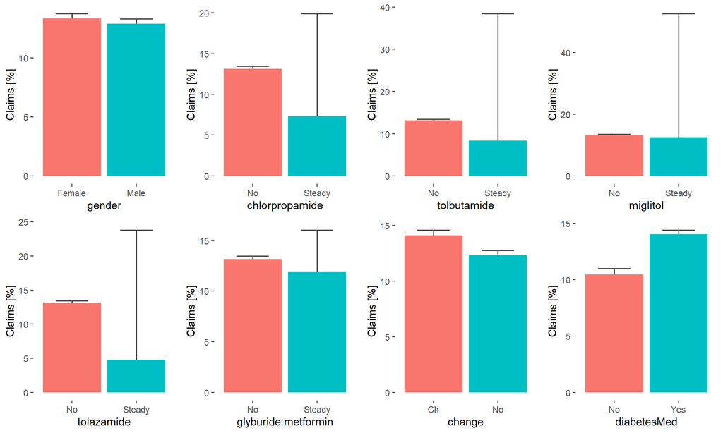

```r
plot_data <- diabetic_data_bin %>%
  dplyr::select(
    dplyr::all_of(merkmale_info %>%
                    dplyr::filter(Gruppe == "Gruppe_2" | Merkmal == "TARGET") %>%
                    dplyr::pull(Merkmal)))
merkmale <- colnames(plot_data)
merkmale <- merkmale[!(merkmale == "TARGET")]

tmp <- generate_plot_claims(plot_data, merkmale = merkmale, plot_type = 1, nr_col = 4)
```

Die Merkmale *change* und *diabetesMed* zeigen eine geringe Streuung der Zielvariable bei gleichzeitig hohem Unterschied im Durchschnitt. Diese Merkmale können eine hohe Signifikanz in der Modellierung haben. Die hohe Streuung in allen Ausprägung *Steady* kann auf die geringe Anzahl von Beobachtungen zurückzuführen sein (siehe Grafiken im vorigen Abschnitt).

**Kategorielle Variablen mit mehr als zwei und weniger als 10 Ausprägungen (Gruppe 3)**

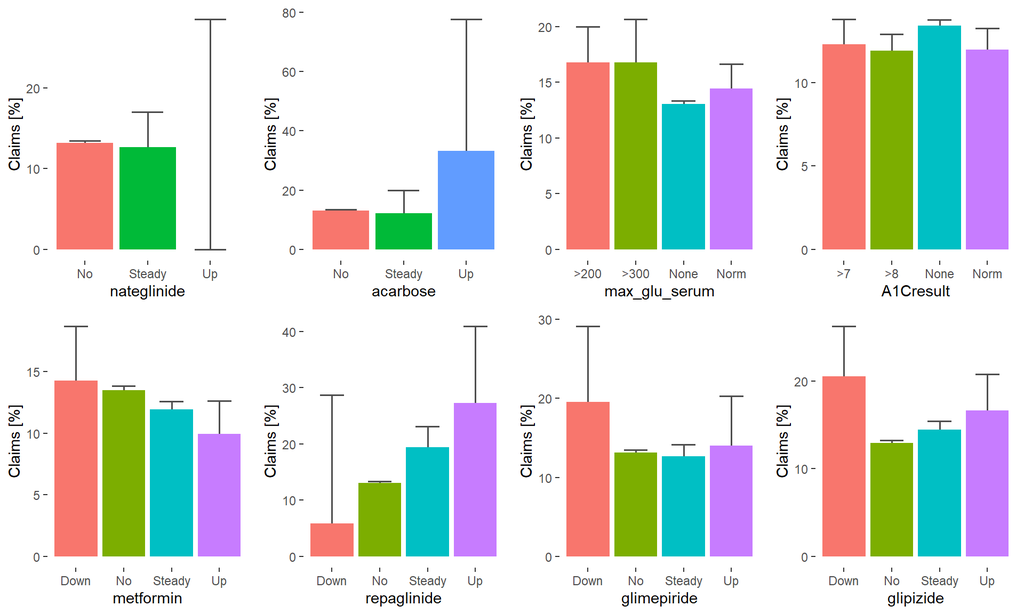

```r
plot_data <- diabetic_data_bin %>%
  dplyr::select(
    dplyr::all_of(merkmale_info %>%
                    dplyr::filter(Gruppe == "Gruppe_3" | Merkmal == "TARGET") %>%
                    dplyr::pull(Merkmal)))
merkmale <- colnames(plot_data)
merkmale <- merkmale[!(merkmale == "TARGET")]

tmp <- generate_plot_claims(plot_data, merkmale = merkmale[1:8], plot_type = 1, nr_col = 4)
```

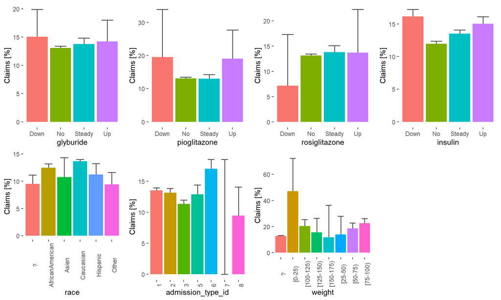

```r
tmp <- generate_plot_claims(plot_data, merkmale = merkmale[9:15], plot_type = 1, nr_col = 4)
```

**Kategorielle Variablen mit 10 oder mehr Ausprägungen (Gruppe 4)**

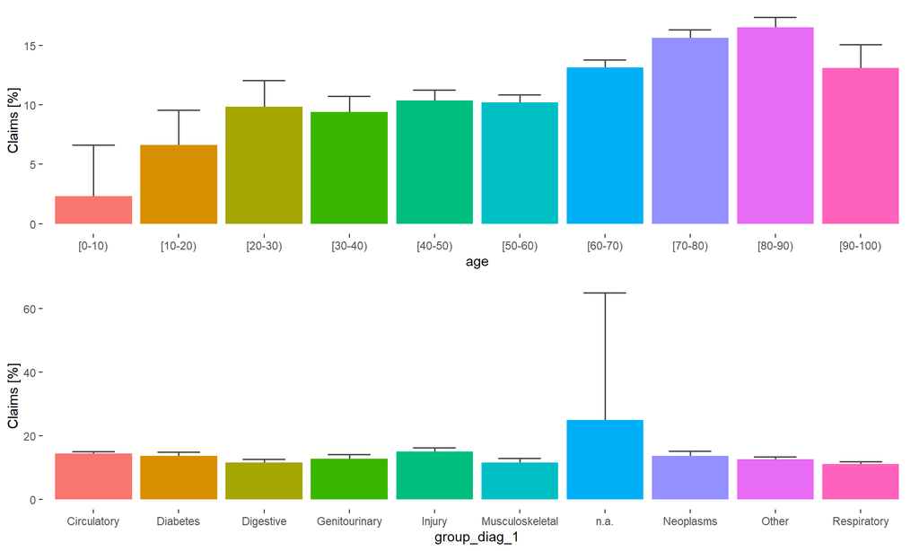

```r
plot_data <- diabetic_data_bin %>%
  dplyr::select(
    dplyr::all_of(merkmale_info %>%
                    dplyr::filter(Gruppe == "Gruppe_4" | Merkmal == "TARGET") %>%
                    dplyr::pull(Merkmal)))
merkmale <- colnames(plot_data)
merkmale <- merkmale[!(merkmale == "TARGET")]

tmp <- generate_plot_claims(plot_data, merkmale = merkmale[1:2], plot_type = 1, nr_col = 1)
```

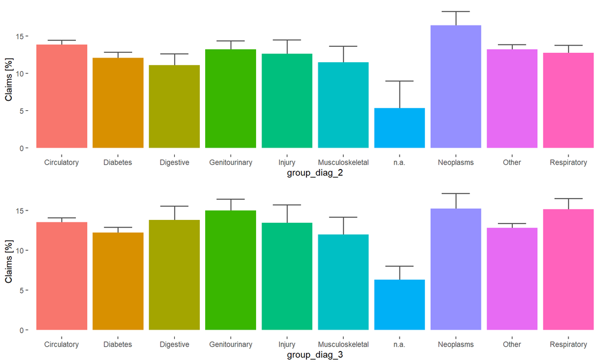

```r
tmp <- generate_plot_claims(plot_data, merkmale = merkmale[3:4], plot_type = 1, nr_col = 1)
```

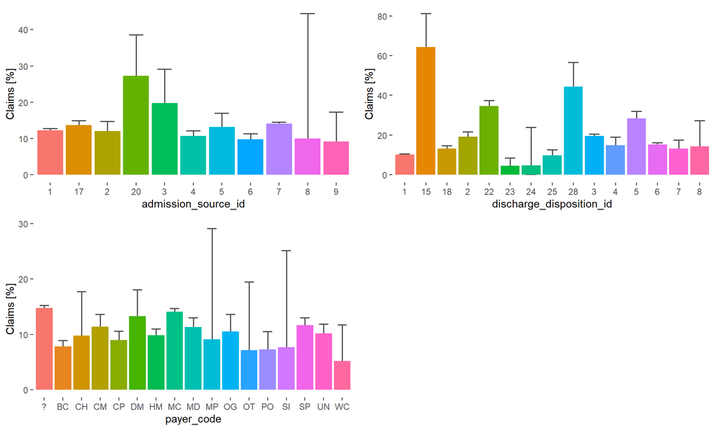

```r
tmp <- generate_plot_claims(plot_data, merkmale = merkmale[5:7], plot_type = 1, nr_col = 2)
```

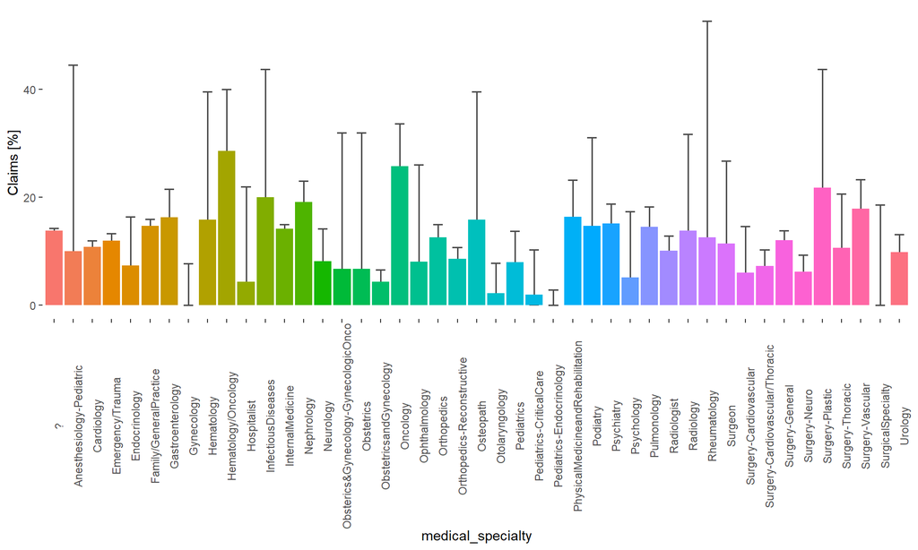

```r
tmp <- generate_plot_claims(plot_data, merkmale = merkmale[8], plot_type = 1, nr_col = 1, angle = 1)
```

Die Merkmale *age*, *group_diag_1*, *group_diag_2*, *group_diag_3*, *discharge_disposition_id* und *admission_source_id* könnten nach dem Überlegungen zu Beginn des Abschnitts signifikant in der Modellierung sein, da sie (relativ) niedrige Streuung bei unterschiedlichen Durchschnittswerten zeigen.

**Integer-Variablen (Gruppe 5)**

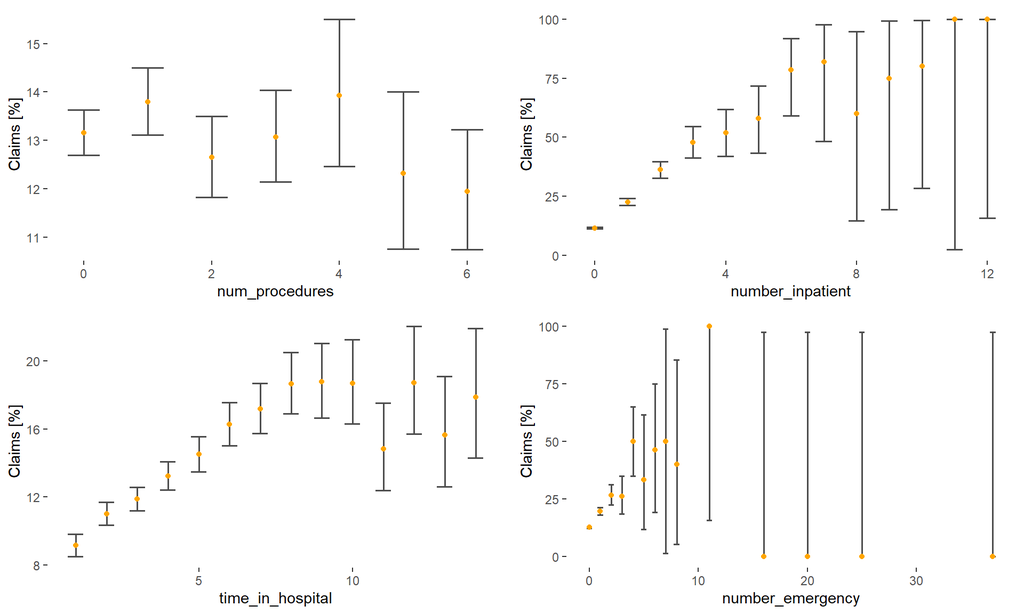

```r
plot_data <- diabetic_data_bin %>%
  dplyr::select(
    dplyr::all_of(merkmale_info %>%
                    dplyr::filter(Gruppe == "Gruppe_5" | Merkmal == "TARGET") %>%
                    dplyr::pull(Merkmal)))
merkmale <- colnames(plot_data)
merkmale <- merkmale[!(merkmale == "TARGET")]

tmp <- generate_plot_claims(plot_data, merkmale = merkmale[1:4], plot_type = 2, nr_col = 2)
```

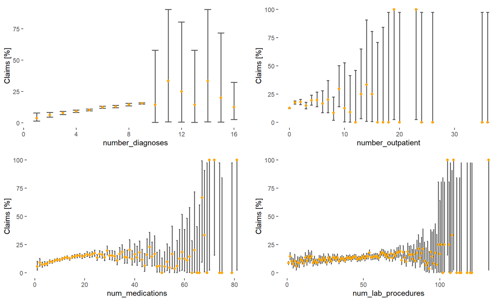

```r
tmp <- generate_plot_claims(plot_data, merkmale = merkmale[5:8], plot_type = 2, nr_col = 2)
```

Die Merkmale *number_inpatient*, *time_in_hospital*, *number_diagnoses* und *num_medications* zeigen in den Bereichen mit einer hohen Anzahl von Beobachtungen (siehe vorigen Abschnitt) eine geringe Streuung der Zielvariablen bei unterschiedlichen Durchschnittswerten und könnten sigifikant für die Modellierung sein.